# Zhaoxin Ban Homework 2

Question 1 Validate the estimate for effective degrees of freedom in Wilks Equation 5.12 via simulation. (a) Produce sets of random AR(1) time series of length 100 with autocorrelation coeffcients -0.9, -0.8, …, 0, 0.1, 0.2, …, 0.9.

```r
autocf <- seq(-0.9,0.9,0.1)
ar.sim=array(0,dim=c(length(autocf),100))
for(i in 1:length(autocf)){
  ar.sim[i,1] <- runif(1,-10,10)
  for(j in 2:100){
    ar.sim[i,j] <- ar.sim[i,j-1]*autocf[i]+rnorm(1,0,1)
  }
}
```

(b)&(c) Calculate the empirical variance of the means of each set of time series with a given autocorrelation coeffcient.Use the empirical variance to estimate the effective sample size for sampling variance of the mean.

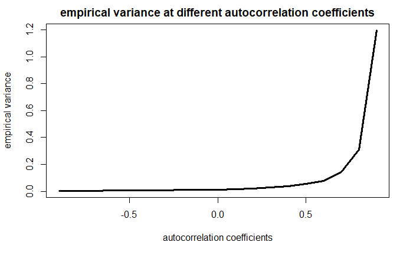

```r
effn <- rep(0,length(autocf))
varxbar=rep(0,length(autocf))
for(i in 1:length(autocf)){
  ar.sim=array(0,dim=c(10000,100))
  xbar=rep(0,10000)
  s2=rep(0,10000)
  for(j in 1:10000){
    ar.sim[j,1]=runif(1,-10,10)
    for(k in 2:100){
      ar.sim[j,k]=ar.sim[j,k-1]*autocf[i]+rnorm(1,0,1)
    }
    xbar[j]=mean(ar.sim[j,])
    s2[j]=var(ar.sim[j,])
  }
  varxbar[i]=var(xbar)
  s2avg=mean(s2)
  effn[i]=s2avg/varxbar[i]
}
plot(x=autocf,y=varxbar,type='l',lwd=3,xlab="autocorrelation coefficients",ylab="empirical variance")
title(lwd=2, main="empirical variance at different autocorrelation coefficients")
```

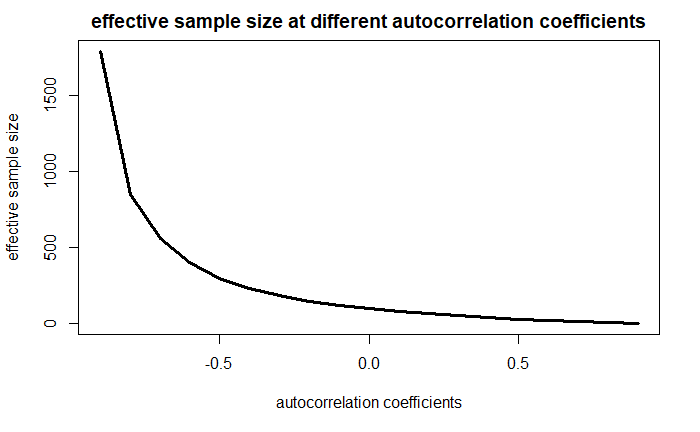

```r
plot(x=autocf,y=effn,type='l',lwd=3,xlab="autocorrelation coefficients",ylab="effective sample size")
title(lwd=2, main="effective sample size at different autocorrelation coefficients")
```

4. Plot your estimate vs. the estimate in Wilks Equation 5.12. How well do they agree?

```r
sizen=rep(0,length(autocf))
for (i in 1:length(autocf)){
  sizen[i]=100*(1-autocf[i])/(1+autocf[i])
}
plot(effn,type='l',col="black",lwd=3)
lines(sizen,col="green",lwd=3)
```

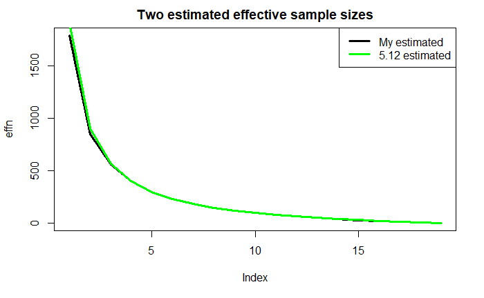

```r
legend("topright",c("My estimated","5.12 estimated"),col=c("black","green"),lwd=3)
title(lwd=2, main="Two estimated effective sample sizes")
```

They agreed very well, almost identical. 2. Experiment with using the block bootstrap to assess uncertainty in the trends in correlated data. (a) Start with a single correlation coefficient for an AR(1) process, and produce a dataset" of length 100.

```r
acf=0.5
ar1=rep(0,100)
ar1[1]=rnorm(1,0,4/3)
for(i in 2:100){
  ar1[i]=ar1[i-1]*acf+rnorm(1,0,1)
}
```

2. Calculate the empirical trend in your data using ordinary least squares. Also calculate the expected variance in your estimator using standard methods that assume independence of the data points.

```r
##if using y=ax+b, a is the record index, then the a is the empirical trend we are looking for, according to OLS, a=cov(x,y)/var(x)
index=seq(1,100,1)
index=index-mean(index)
COV<- function(x,y) {
  if(length(x)!=length(y)) {stop('x must have the same length as y ')}
  x.bar <- mean(x)
  y.bar <- mean(y)
  N <- length(x)
  Cov <- (sum((x-x.bar)*(y-y.bar))) / (N-1)
  return(Cov)
}
##Calculate trend, named a
a <- COV(index,ar1)/var(index)
##Calculate the other parameter in OLS, named b, then y=ax+b
b <- mean(ar1)-a*mean(index)
estimator <- a*index+b
n=100
variance <- 1/(n-2)*sum((ar1-estimator)^2)/sum((index)*(index))
print(paste0("variance=",variance))
```

```
[1] "variance=1.49590232069152e-05"
```

3. Choose an appropriate block size based on equation 5.36 in Wilks. Justify your block size in terms of the autocorrelation properties of the data. Perform a block bootstrap on your data many times (e.g. 10000), recalculate the OLS trend for each resampled time series, and use the distribution of trends to estimate the variance in the OLS estimator for your dataset. How does the block bootstrap estimate compare with the standard estimate from (b)?

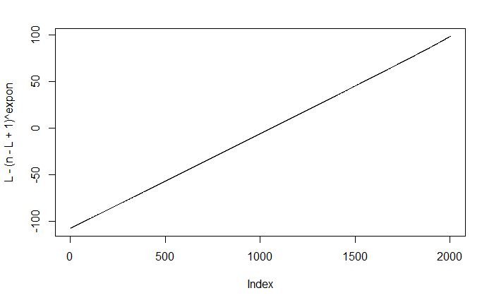

```r
###lag-1 autocorrelation coefficient###
xminus <- ar1[1:99]
xplus <- ar1[2:100]
r1 <- sum((xminus-mean(xminus))*(xplus-mean(xplus)))/((sqrt(sum((xminus-mean(xminus))^2)))*(sqrt(sum((xminus-mean(xminus))^2))))
n1 <- n*(1-r1)/(1+r1)
expon <- 2/3*(1-n1/n) ###Now the Wilks 5.36 becomes L=(101-L)^(expon)
fL <- function(L,expon){
  n=100
  result <- L-(n-L+1)^expon
  return(result)
}
##Check the approximate location of root of fL##
L=seq(-100,100,0.1)
plot(L-(n-L+1)^expon,type='l') ##see whether this interval contains root, the result is "yes"
```

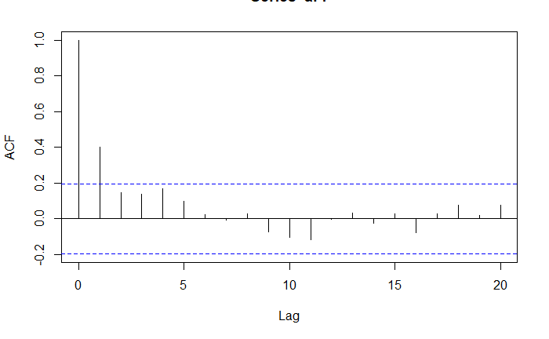

```r
eps=1e-7
max=max(L)
min=min(L)
tmp=0.5*(max+min)
check <- fL(tmp,expon)
while(abs(check)>eps){
  if(check<0){
    min=tmp
    tmp=0.5*(max+min)
  }else{
    max=tmp
    tmp=0.5*(max+min)
  }
  check <- fL(tmp,expon)
}
L <- round(tmp)
###Check the autocorrelation properties of the data
acff <- acf(ar1)
```

As we can see, the autocorrelation coefficient is overall smaller than the acceptable threshold when Lag>=L.

```r
###block bootstrap for 10000 times without overlap###
nblock <- floor(100/L)
stdp <- sample(1:100,10000,replace=T)
trends=rep(0,10000)
for(i in 1:10000){
  newar=rep(0,100)
  newar[1:(100-stdp[i]+1)]=ar1[stdp[i]:100]
  newar[(100-stdp[i]+2):100]=ar1[1:(stdp[i]-1)]
  sel=sample(1:nblock,nblock,replace=T)
  boot=rep(0,100)
  for(j in 1:nblock){
    boot[((j-1)*L+1):(j*L)]=newar[((sel[j]-1)*L+1):(sel[j]*L)]
  }
  sel=sample(1:nblock,1)
  if(j*L<100){
      boot[(j*L+1):100]=newar[((sel-1)*L+1):((sel-1)*L+1+100-j*L-1)]
  }
  trends[i] <- COV(index[1:100],boot)/var(index[1:100])
}
var(trends)
```

```
[1] 3.308922e-05
```

```r
###block bootstrap for 10000 times with overlap###
trends=rep(0,10000)
nblock <- floor(100-L+1)
arrayblock <- array(0,dim=c(100-L+1,L))
for(i in 1:(100-L+1)){
  arrayblock[i,]=ar1[i:(i+L-1)]
}
for(i in 1:10000){
  selline <- sample(1:nblock,(floor(100/L)+1),replace=T)
  tmp=arrayblock[selline[1],]
  for(j in 2:length(selline)){
    tmp=c(tmp,arrayblock[selline[j],])
  }
  boot=tmp[1:100]
  trends[i] <- COV(index[1:100],boot)/var(index[1:100])
}
var(trends)
```

```
[1] 3.260033e-05
```

```r
###Check the bootstrap method using r built-in package###
library(boot)
trend <- function(data){
  index <- seq(1,100,1)
  mm <- COV(index,data)/var(index)
  return(mm)
}
test <- tsboot(ar1,trend,R=10000,l=L,sim="fixed",endcorr=FALSE,n.sim=100,orig.t=FALSE)
var(test$t)
```

```
             [,1]
[1,] 3.263892e-05
```

```r
###So I am going to choose the overlapped method of bootstrap###
variance_c <- var(trends)
print(paste0("variance=",variance_c))
```

```
[1] "variance=3.26003347645568e-05"
```

This variance is larger compared with the variance obtained in question (b) (d) Since we know the generating process for our data, we can again estimate the uncertainty in our slope by generating many more random datasets from the same process. (Note that for an AR(1) process, we could also estimate Var(beta) analytically.) How does this estimate of variance compare to our bootstrap estimate?

```r
tt=rep(0,10000) ##This is used for storing the trend for random datasets
for(i in 1:10000){
  datai=rep(0,100)
  datai[1]=rnorm(1,0,4/3)
  for(j in 2:100){
    datai[j]=datai[j-1]*0.5+rnorm(1,0,1)
  }
  tt[i]=trend(datai)
}
var(tt)
```

```
[1] 4.675038e-05
```

```r
variance_d <- var(tt)
###Check the results using built-in function of AR(1)
mmm=rep(0,10000)
tt1=rep(0,10000)
for(i in 1:10000){
  datai <- arima.sim(model=list(ar=0.5),n=100)
  tt1[i]=trend(datai)
  mmm[i]=datai[1]
}
var(tt1)
```

```
[1] 4.613477e-05
```

```r
print(paste0("variance=",variance_d))
```

```
[1] "variance=4.67503791734533e-05"
```

This variance is larger than the variances obtained from question (b) and question (c), because the previous two have a certain degree of underestimation of the variance. 3. (a) Calculate and plot summer-season (JJA) CDD and winter-season (DJF) HDD for Los Angeles, assigning the winter year to the January.

```r
setwd("C:/Users/zban/Downloads/2019 winter quarter/Modern Environmental Statistics/")
Tmax=read.table("USW00023174_TMAX_clean.csv",sep=",",header=T)
Tmin=read.table("USW00023174_TMIN_clean.csv",sep=",",header=T)
ind1 <- which(Tmax[,5]!=-999.9)
ind2 <- which(Tmin[,5]!=-999.9)
ind <- intersect(ind1,ind2)
Tmax=Tmax[ind,]
Tmin=Tmin[ind,]
##Calculate summer-season CDD, first select summer-season
Tmax_JJA <- Tmax[which((Tmax[,2]==6)|(Tmax[,2]==7)|(Tmax[,2]==8)),5]
Tmin_JJA <- Tmin[which((Tmin[,2]==6)|(Tmin[,2]==7)|(Tmin[,2]==8)),5]
Date_JJA <- Tmax[which((Tmax[,2]==6)|(Tmax[,2]==7)|(Tmax[,2]==8)),1:3]
##Calculate winter-season HDD, first select winter-season
Tmax_DJF <- Tmax[which((Tmax[,2]==12)|(Tmax[,2]==1)|(Tmax[,2]==2)),5]
Tmin_DJF <- Tmin[which((Tmin[,2]==12)|(Tmin[,2]==1)|(Tmin[,2]==2)),5]
Date_DJF <- Tmax[which((Tmax[,2]==12)|(Tmax[,2]==1)|(Tmax[,2]==2)),1:3]
CDD=rep(0,length(Tmax_JJA))
HDD=rep(0,length(Tmax_DJF))
for(i in 1:length(CDD)){
  CDD[i]=max(0.5*(Tmax_JJA[i]+Tmin_JJA[i])-20,0)
}
for(i in 1:length(HDD)){
  HDD[i]=max(15-0.5*(Tmax_DJF[i]+Tmin_DJF[i]),0)
}
CDD_wd <- cbind(Date_JJA,CDD)
HDD_wd <- cbind(Date_DJF,HDD)
lJJA <- length(unique(Date_JJA[,1]))-1
lDJF <- length(unique(Date_DJF[,1]))-1
seas_CDD <- rep(0,lJJA)
seas_HDD <- rep(0,lDJF)
for(i in 1:lJJA){
  seas_CDD[i]=sum(CDD_wd[which(CDD_wd[,1]==unique(Date_JJA[,1])[i+1]),4])
}
for(i in 1:lDJF){
  D <- HDD_wd[which((HDD_wd[,1]*100+HDD_wd[,2])==((unique(Date_DJF[,1])[i]))*100+12),]
  J <- HDD_wd[which((HDD_wd[,1]*100+HDD_wd[,2])==((unique(Date_DJF[,1])[i+1])*100+1)),]
  F <- HDD_wd[which((HDD_wd[,1]*100+HDD_wd[,2])==((unique(Date_DJF[,1])[i+1])*100+2)),]
  seas_HDD[i]=sum(c(D[,4],J[,4],F[,4]))
}
plot(x=unique(Date_JJA[,1])[2:length(unique(Date_JJA[,1]))],y=seas_CDD,type='l',lwd=2,ylim=c(0,500),xlab="year",ylab="CDD or HDD")
lines(x=unique(Date_DJF[,1])[2:length(unique(Date_DJF[,1]))],y=seas_HDD,col="red",lwd=2)
```

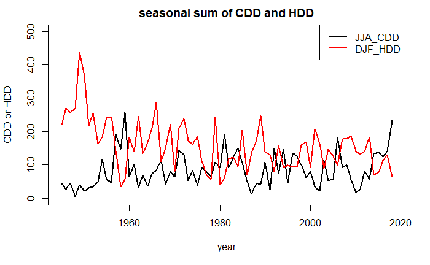

```r
legend("topright",c("JJA_CDD","DJF_HDD"),col=c("black","red"),lwd=2)
title(lwd=2, main="seasonal sum of CDD and HDD")
```

2. Decide and state what to do about missing data in calculating seasonal CDD and HDD.

```r
for(i in 1:lJJA){
  seas_CDD[i]=mean(CDD_wd[which(CDD_wd[,1]==unique(Date_JJA[,1])[i]),4])
}
for(i in 1:lDJF){
  D <- HDD_wd[which((HDD_wd[,1]*100+HDD_wd[,2])==((unique(Date_DJF[,1])[i]))*100+12),]
  J <- HDD_wd[which((HDD_wd[,1]*100+HDD_wd[,2])==((unique(Date_DJF[,1])[i+1])*100+1)),]
  F <- HDD_wd[which((HDD_wd[,1]*100+HDD_wd[,2])==((unique(Date_DJF[,1])[i+1])*100+2)),]
  seas_HDD[i]=mean(c(D[,4],J[,4],F[,4]))
}
plot(x=unique(Date_JJA[,1])[2:length(unique(Date_JJA[,1]))],y=seas_CDD,type='l',lwd=2,ylim=c(0,5),xlab="year",ylab="CDD or HDD")
lines(x=unique(Date_DJF[,1])[2:length(unique(Date_DJF[,1]))],y=seas_HDD,col="red",lwd=2)
```

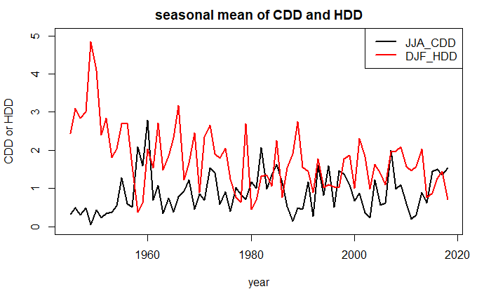

```r
legend("topright",c("JJA_CDD","DJF_HDD"),col=c("black","red"),lwd=2)
title(lwd=2, main="seasonal mean of CDD and HDD")
```

3. Present a few useful exploratory plots of CDD and HDD, and describe the distributions.

```r
par(mfrow=c(1,3))
hist(seas_CDD)
dens_CDD <- density(seas_CDD,adjust=1,kernel=c("gaussian"))
hist(seas_HDD)
```

```r
dens_HDD <- density(seas_HDD,adjust=1,kernel=c("gaussian"))
plot(dens_CDD,lwd=3,main="kernel density plot")
lines(dens_HDD,lwd=3,col="red")
```

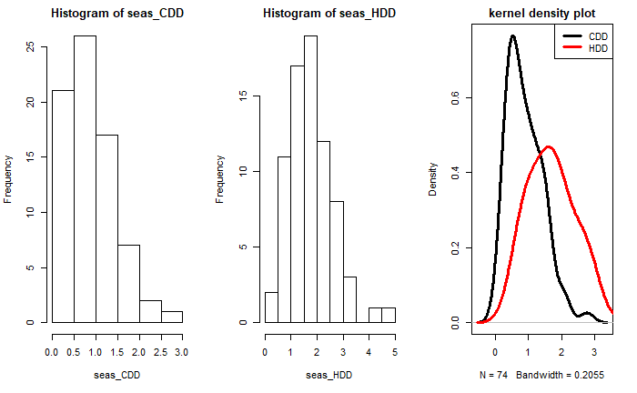

```r
legend("topright",c("CDD","HDD"),col=c("black","red"),lwd=3)
```

Both CDD and HDD show positive skewness probably because they have an arbitrary left boundary of 0. HDD has larger spread, lower peak and is flatter than CDD, indicating HDD has larger variability and CDD is more concentrated. (d) Use whatever testing procedure you think best to test H0: DJF HDD are equal before and after 1980, versus Ha: they are not, and likewise for JJA CDD.

```r
##For DJF HDD##
par(mfrow=c(1,1))
seas_wd_CDD=cbind(unique(Date_JJA[,1])[2:length(unique(Date_JJA[,1]))],seas_CDD)
seas_wd_HDD=cbind(unique(Date_DJF[,1])[2:length(unique(Date_DJF[,1]))],seas_HDD)
bf80_seas_CDD=seas_wd_CDD[which(seas_wd_CDD[,1]<1980),]
af80_seas_CDD=seas_wd_CDD[which(seas_wd_CDD[,1]>1980),]
bf80_seas_HDD=seas_wd_HDD[which(seas_wd_HDD[,1]<1980),]
af80_seas_HDD=seas_wd_HDD[which(seas_wd_HDD[,1]>1980),]
mean1 <- mean(bf80_seas_HDD[,2])
mean2 <- mean(af80_seas_HDD[,2])
denom <- sqrt(var(bf80_seas_HDD[,2])/length(bf80_seas_HDD[,2])+var(af80_seas_HDD[,2])/length(af80_seas_HDD[,2]))
Z <- (mean1-mean2)/denom
p=1-pnorm(Z,sd=1,mean=0)
print(paste0("p(z>Z)=",p,"<0.005"))
```

```
[1] "p(z>Z)=7.21413670892179e-05<0.005"
```

Reject null hypothesis, DJF HDD are not equal before and after 1980 under 0.01 significance level.

```r
##For JJA CDD##
##check for CDD if their mean are the same##
mean1 <- mean(bf80_seas_CDD[,2])
mean2 <- mean(af80_seas_CDD[,2])
denom <- sqrt(var(bf80_seas_CDD[,2])/length(bf80_seas_CDD[,2])+var(af80_seas_CDD[,2])/length(af80_seas_CDD[,2]))
Z <- (mean1-mean2)/denom
p=pnorm(Z,sd=1,mean=0)
print(paste0("p(z<Z)=",p,">0.005"))
```

```
[1] "p(z<Z)=0.0936798879728598>0.005"
```

Accept null hypothesis, JJA CDD are equal before and after 1980 under 0.01 significance level.

5. Fit a regression model to the HDD, using an intercept and centered time as predictors, and likewise for CDD. That is, fit a univariate regression model with an intercept, using as a predictor the year, after removing the mean of the vector of years. Centering the predictor aids the interpretation of results, as the y-intercept then corresponds to the expected value in the middle of the time interval. Are there significant trends? Discuss, and compare results with the previous part.

```r
Date=Date_JJA
par(mfrow=c(1,2))
###Fit regression model to HDD and CDD
len=length(unique(Date[,1]))
predictor <- unique(Date[,1])[2:len]-mean(unique(Date[,1])[2:len])
Y_HDD <- seas_HDD
##Calculate trend, named a
a_HDD <- COV(predictor,Y_HDD)/var(predictor)
##Calculate the other parameter in OLS, named b, then y=ax+b
b_HDD <- mean(Y_HDD)-a*mean(predictor)
estimator_HDD <- a_HDD*predictor+b_HDD
plot(Y_HDD,col="blue",type="p")
lines(estimator_HDD,lwd=3,col="red")
```

```r
print(paste0("For HDD: y=ax+b,a=",a_HDD,"b=",b_HDD))
```

```
[1] "For HDD: y=ax+b,a=-0.0187317610477743b=1.76373174899037"
```

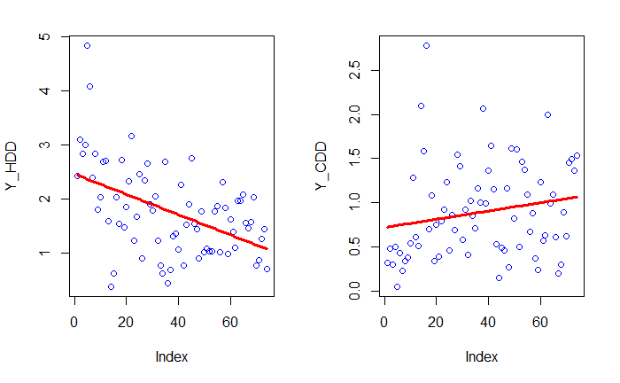

```r
Y_CDD <- seas_CDD
##Calculate trend, named a
a_CDD <- COV(predictor,Y_CDD)/var(predictor)
##Calculate the other parameter in OLS, named b, then y=ax+b
b_CDD <- mean(Y_CDD)-a*mean(predictor)
estimator_CDD <- a_CDD*predictor+b_CDD
plot(Y_CDD,col="blue",type="p")
lines(estimator_CDD,lwd=3,col="red")
```

```r
print(paste0("For CDD: y=ax+b,a=",a_CDD,"b=",b_CDD))
```

```
[1] "For CDD: y=ax+b,a=0.00467424133304306b=0.892934350238942"
```

Check if there are significant trends in both CDD and HDD, build statistics to check the significance

```r
##For DJF HDD##
n=length(Y_HDD)
A_HDD=(a_HDD-0)/sqrt(1/(n-2)*sum((Y_HDD-estimator_HDD)^2)/sum((index-mean(index))^2))
print(paste0("test statistic A_HDD=",A_HDD))
```

```
[1] "test statistic A_HDD=-7.34172193637396"
```

```r
qt(0.005, 72, lower.tail = TRUE, log.p = FALSE)
```

```
[1] -2.645852
```

-7.34<-2.645852, which is the critical value at 0.01 significance level, so reject null hypothesis, DJF HDD has significant trend. This is consistent with the previous part in question (d).

```r
##For JJA CDD##
n=length(Y_CDD)
A_CDD=(a_CDD-0)/sqrt(1/(n-2)*sum((Y_CDD-estimator_CDD)^2)/sum((index-mean(index))^2))
print(paste0("test statistic A_CDD=",A_CDD))
```

```
[1] "test statistic A_CDD=2.52600938193679"
```

```r
qt(0.995, 72, lower.tail = TRUE, log.p = FALSE)
```

```
[1] 2.645852
```

2.526<2.645852, which is the critical value at 0.01 significance level, so accept null hypothesis, JJA CDD has no significant trend. This is consistent with the previous part in question (d).

4.(a)

```r
#Choose NINO3.4, NINO4 (1870-now, HadISST1)
#SOI(1866-now,Jones),
#PDO(Mantua, U. Washington)
#NAO Gibraltar-Stykkisholmur
#AMO derived from HadSST SST SST EQ-60°N, 0°-80°W minus SST 60°S-60°N
#CRUTEM4 global land temperature
###Download and clean data###
nyr=2018-1944+1
month=rep(seq(1,12),nyr)
NINO3.4=read.table("NINO3.4.txt",skip=40)
NINO3.4=NINO3.4[which(NINO3.4[,1]>=1944),]
year=c(floor(NINO3.4[,1]),2018)
NINO3.4=cbind(year[1:length(NINO3.4[,2])],month[1:length(NINO3.4[,2])],NINO3.4[,2])
NINO4=read.table("NINO4.txt",skip=40)
NINO4=NINO4[which(NINO4[,1]>=1944),]
NINO4=cbind(year[1:length(NINO4[,2])],month[1:length(NINO4[,2])],NINO4[,2])
SOI=read.table("SOI Jones.txt",skip=40)
getindex <- function(index){
  index1=index[which(index[,1]>=1944),]
  tmp=rep(0,12*nyr)
  for(i in 1:nyr){
    tmp[((i-1)*12+1):(i*12)]=as.numeric(index1[i,2:13])
  }
  index2=cbind(year[1:length(tmp)],month[1:length(tmp)],tmp)
}
SOI=getindex(SOI)
PDO=read.table("PDO.txt",skip=40)
```

```
number of items read is not a multiple of the number of columns
```

```r
PDO=getindex(PDO)
NAO=read.table("NAO.txt",skip=40)
NAO=getindex(NAO)
AMO=read.table("AMO.txt",skip=40)
AMO=getindex(AMO)
landT=read.table("landtemp.txt",skip=40)
landT=landT[which(landT[,1]>=1944),]
###create predictors for summer CDD###
getMAM <- function(index){
  tmp=index[which((index[,2]==3)|(index[,2]==4)|(index[,2]==5)),]
  l=length(unique(tmp[,1]))-1
  out=rep(0,l)
  for(i in 1:l){
    out[i]=mean(tmp[which(tmp[,1]==unique(tmp[,1])[i+1]),3])
  }
  out1 <- cbind(unique(tmp[,1])[2:(l+1)],out)
  return(out1)
}
getSON <- function(index){
  index=index[which(index[,3]!=-999.9),]
  tmp=index[which((index[,2]==9)|(index[,2]==10)|(index[,2]==11)),]
  l=length(unique(tmp[,1]))-1
  out=rep(0,l)
  for(i in 1:l){
    out[i]=mean(tmp[which(tmp[,1]==unique(tmp[,1])[i]),3])
  }
  out1 <- cbind(unique(tmp[,1])[2:(l+1)],out)
  return(out1)
}
#1.Nino3.4 averaged over MAM
NINO3.4MAM=getMAM(NINO3.4)
#2.SOI averaged over MAM
SOIMAM=getMAM(SOI)
#3.PDO averaged over MAM
PDOMAM=getMAM(PDO)
#4.landT averaged over MAM
landTMAM=getMAM(landT)
NINO4MAM=getMAM(NINO4)
NAOMAM=getMAM(NAO)
AMOMAM=getMAM(AMO)
###create predictors for winter HDD###
#1.Nino4 averaged over SON
NINO4SON=getSON(NINO4)
#2.NAO averaged over SON
NAOSON=getSON(NAO)
#3.AMO averaged over SON
AMOSON=getSON(AMO)
#4.landT averaged over MAM
landTSON=getSON(landT)
seas_HDD=cbind(landTSON[,1],seas_HDD)
seas_CDD=cbind(landTSON[,1],seas_CDD)
par(mfrow=c(2,4))
plot(NINO3.4MAM,type='l',xlab="year", ylab="NINO3.4-MAM", lwd=2, main="NINO3.4-MAM")
plot(SOIMAM,type='l',xlab="year", ylab="SOI-MAM", lwd=2, main="SOI-MAM")
```

```r
plot(PDOMAM,type='l',xlab="year", ylab="PDO-MAM", lwd=2, main="PDO-MAM")
plot(landTMAM,type='l',xlab="year", ylab="landT-MAM", lwd=2, main="landT-MAM")
```

```r
plot(NINO4SON,type='l',xlab="year", ylab="NINO4-SON", lwd=2, main="NINO4-SON")
plot(NAOSON,type='l',xlab="year", ylab="NAO-SON", lwd=2, main="NAO-SON")
```

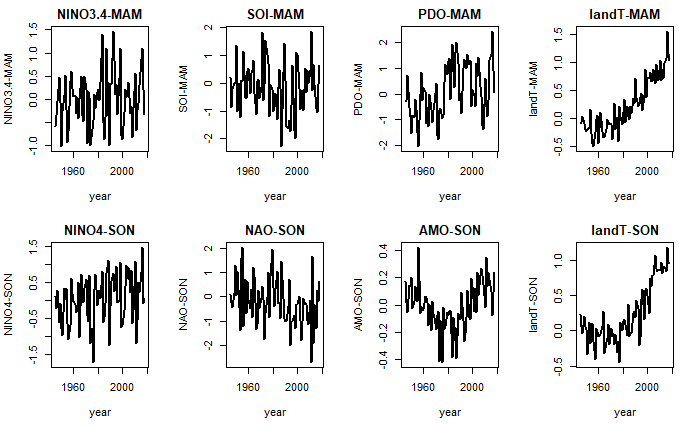

```r
plot(AMOSON,type='l',xlab="year", ylab="AMO-SON", lwd=2, main="AMO-SON")
plot(landTSON,type='l',xlab="year", ylab="landT-SON", lwd=2, main="landT-SON")
```

2. Examine the covariance matrix of your predictors. Is there collinearity? If so, change your predictors to reduce collinearity, and explain.

```r
MAM <- cbind(NINO3.4MAM[,2],SOIMAM[,2], PDOMAM[,2],landTMAM[,2])
k=ncol(MAM)
n=nrow(MAM)
MAM_mean <- matrix(data=1, nrow=n) %*% cbind(mean(NINO3.4MAM[,2]),mean(SOIMAM[,2]),mean(PDOMAM[,2]),mean(landTMAM[,2]))
DMAM=MAM-MAM_mean
CMAM=(n-1)^-1*t(DMAM)%*%DMAM
SON <- cbind(NINO4SON[,2],NAOSON[,2],AMOSON[,2],landTSON[,2])
k=ncol(SON)
n=nrow(SON)
SON_mean <- matrix(data=1, nrow=n) %*% cbind(mean(NINO4SON[,2]),mean(NAOSON[,2]),mean(AMOSON[,2]),mean(landTSON[,2]))
DSON=SON-SON_mean
CSON=(n-1)^-1*t(DSON)%*%DSON
nameSON=c("NINO4-SON","NAO-SON","AMO-SON","landT-SON")
nameMAM=c("NINO3.4-MAM","SOI-MAM","PDO-MAM","landT-MAM")
colnames(CSON)=nameSON
rownames(CSON)=nameSON
colnames(CMAM)=nameMAM
rownames(CMAM)=nameMAM
print("Covariance matrix of MAM predictors:")
```

```
[1] "Covariance matrix of MAM predictors:"
```

```r
CMAM
```

```
            NINO3.4-MAM     SOI-MAM    PDO-MAM   landT-MAM
NINO3.4-MAM   0.3267398 -0.39712752  0.3300911  0.07182280
SOI-MAM      -0.3971275  0.79499135 -0.4671037 -0.07590614
PDO-MAM       0.3300911 -0.46710369  1.0612289  0.21261929
landT-MAM     0.0718228 -0.07590614  0.2126193  0.21573830
```

```r
print("Covariance matrix of SON predictors:")
```

```
[1] "Covariance matrix of SON predictors:"
```

```r
CSON
```

```
            NINO4-SON     NAO-SON     AMO-SON   landT-SON
NINO4-SON  0.44329974 -0.09196667 -0.02737127  0.07623270
NAO-SON   -0.09196667  0.92805871 -0.02771861 -0.09464386
AMO-SON   -0.02737127 -0.02771861  0.02912087  0.03808340
landT-SON  0.07623270 -0.09464386  0.03808340  0.17092598
```

```r
par(mfrow=c(1,1))
df_CDD <- as.data.frame(cbind(seas_CDD[,2],NINO3.4MAM,SOIMAM[,2],PDOMAM[,2],landTMAM[,2]))
df_CDD <- df_CDD[which(df_CDD[,2]<=2005),]  ##withheld year2005 and after year 2005
colnames(df_CDD) <- c("CDD","time","NINO3.4","SOI","PDO","landT")
md1 <-lm(CDD~NINO3.4,data=df_CDD)
summary(md1)
```

```
Call:
lm(formula = CDD ~ NINO3.4, data = df_CDD)

Residuals:
    Min      1Q  Median      3Q     Max
-0.8123 -0.4259 -0.0708  0.3261  1.9044

Coefficients:
            Estimate Std. Error t value Pr(>|t|)
(Intercept)  0.87074    0.06946  12.535   <2e-16 ***
NINO3.4      0.11720    0.12140   0.965    0.338
---
Signif. codes:  0 *** 0.001 ** 0.01 * 0.05 . 0.1   1

Residual standard error: 0.5419 on 59 degrees of freedom
Multiple R-squared:  0.01555,   Adjusted R-squared:  -0.001135
F-statistic: 0.932 on 1 and 59 DF,  p-value: 0.3383
```

```r
md2 <-lm(CDD~time,data=df_CDD)
summary(md2)
```

```
Call:
lm(formula = CDD ~ time, data = df_CDD)

Residuals:
    Min      1Q  Median      3Q     Max
-0.7895 -0.3997 -0.1158  0.2706  1.9905

Coefficients:
             Estimate Std. Error t value Pr(>|t|)
(Intercept) -8.988194   7.738687  -1.161    0.250
time         0.004990   0.003918   1.274    0.208

Residual standard error: 0.5388 on 59 degrees of freedom
Multiple R-squared:  0.02676,   Adjusted R-squared:  0.01026
F-statistic: 1.622 on 1 and 59 DF,  p-value: 0.2078
```

```r
md3 <-lm(CDD~SOI,data=df_CDD)
summary(md3)
```

```
Call:
lm(formula = CDD ~ SOI, data = df_CDD)

Residuals:
    Min      1Q  Median      3Q     Max
-0.8049 -0.4141 -0.1236  0.2951  1.9551

Coefficients:
            Estimate Std. Error t value Pr(>|t|)
(Intercept)  0.85601    0.07159  11.958   <2e-16 ***
SOI         -0.05356    0.07703  -0.695     0.49
---
Signif. codes:  0 *** 0.001 ** 0.01 * 0.05 . 0.1   1

Residual standard error: 0.5439 on 59 degrees of freedom
Multiple R-squared:  0.008128,  Adjusted R-squared:  -0.008684
F-statistic: 0.4835 on 1 and 59 DF,  p-value: 0.4896
```

```r
md4 <-lm(CDD~PDO,data=df_CDD)
summary(md4)
```

```
Call:
lm(formula = CDD ~ PDO, data = df_CDD)

Residuals:
    Min      1Q  Median      3Q     Max
-0.8079 -0.3978 -0.1044  0.3201  1.9010

Coefficients:
            Estimate Std. Error t value Pr(>|t|)
(Intercept)  0.86261    0.06939  12.431   <2e-16 ***
PDO          0.07432    0.06865   1.083    0.283
---
Signif. codes:  0 *** 0.001 ** 0.01 * 0.05 . 0.1   1

Residual standard error: 0.5408 on 59 degrees of freedom
Multiple R-squared:  0.01948,   Adjusted R-squared:  0.002859
F-statistic: 1.172 on 1 and 59 DF,  p-value: 0.2834
```

```r
md5 <-lm(CDD~landT,data=df_CDD)
summary(md5)
```

```
Call:
lm(formula = CDD ~ landT, data = df_CDD)

Residuals:
    Min      1Q  Median      3Q     Max
-0.8133 -0.4041 -0.1089  0.2952  1.9244

Coefficients:
            Estimate Std. Error t value Pr(>|t|)
(Intercept)  0.86608    0.07207  12.017   <2e-16 ***
landT        0.01663    0.20158   0.082    0.935
---
Signif. codes:  0 *** 0.001 ** 0.01 * 0.05 . 0.1   1

Residual standard error: 0.5461 on 59 degrees of freedom
Multiple R-squared:  0.0001153, Adjusted R-squared:  -0.01683
F-statistic: 0.006803 on 1 and 59 DF,  p-value: 0.9345
```

The time predictor has the smallest MSE, largest R2 and the largest F ratio, so choose time as the first predictor. The remaining predictor would reduce the R2 by an amount larger than 0.05%, so we choose to continue adding predictors.

```r
md1 <- lm(CDD~time+NINO3.4,data=df_CDD)
md2 <- lm(CDD~time+SOI,data=df_CDD)
md3 <- lm(CDD~time+PDO,data=df_CDD)
md4 <- lm(CDD~time+landT,data=df_CDD)
summary(md1)
```

```
Call:
lm(formula = CDD ~ time + NINO3.4, data = df_CDD)

Residuals:
     Min       1Q   Median       3Q      Max
-0.81043 -0.42931 -0.08382  0.26814  1.97352

Coefficients:
             Estimate Std. Error t value Pr(>|t|)
(Intercept) -7.912456   7.898964  -1.002    0.321
time         0.004447   0.003999   1.112    0.271
NINO3.4      0.092368   0.123197   0.750    0.456

Residual standard error: 0.5408 on 58 degrees of freedom
Multiple R-squared:  0.0361,    Adjusted R-squared:  0.002862
F-statistic: 1.086 on 2 and 58 DF,  p-value: 0.3443
```

```r
summary(md2)
```

```
Call:
lm(formula = CDD ~ time + SOI, data = df_CDD)

Residuals:
    Min      1Q  Median      3Q     Max
-0.7788 -0.4141 -0.1045  0.2475  2.0079

Coefficients:
             Estimate Std. Error t value Pr(>|t|)
(Intercept) -8.210048   8.032313  -1.022    0.311
time         0.004593   0.004069   1.129    0.264
SOI         -0.031772   0.079242  -0.401    0.690

Residual standard error: 0.5427 on 58 degrees of freedom
Multiple R-squared:  0.02945,   Adjusted R-squared:  -0.00402
F-statistic: 0.8799 on 2 and 58 DF,  p-value: 0.4203
```

```r
summary(md3)
```

```
Call:
lm(formula = CDD ~ time + PDO, data = df_CDD)

Residuals:
    Min      1Q  Median      3Q     Max
-0.8169 -0.4187 -0.1001  0.2678  1.9650

Coefficients:
             Estimate Std. Error t value Pr(>|t|)
(Intercept) -6.636723   9.270014  -0.716    0.477
time         0.003798   0.004695   0.809    0.422
PDO          0.038359   0.081958   0.468    0.642

Residual standard error: 0.5424 on 58 degrees of freedom
Multiple R-squared:  0.03042,   Adjusted R-squared:  -0.003014
F-statistic: 0.9098 on 2 and 58 DF,  p-value: 0.4083
```

```r
summary(md4)
```

```
Call:
lm(formula = CDD ~ time + landT, data = df_CDD)

Residuals:
    Min      1Q  Median      3Q     Max
-0.7601 -0.3461 -0.1084  0.2793  1.8545

Coefficients:
              Estimate Std. Error t value Pr(>|t|)
(Intercept) -22.904781  12.209257  -1.876   0.0657 .
time          0.012057   0.006193   1.947   0.0564 .
landT        -0.460280   0.314324  -1.464   0.1485
---
Signif. codes:  0 *** 0.001 ** 0.01 * 0.05 . 0.1   1

Residual standard error: 0.5337 on 58 degrees of freedom
Multiple R-squared:  0.06146,   Adjusted R-squared:  0.02909
F-statistic: 1.899 on 2 and 58 DF,  p-value: 0.1589
```

The landT predictor has the smallest MSE, largest R2 and the highest F ratio this time, so choose landT as the second predictor. The remaining predictor would reduce the R2 by an amount larger than 0.05%, so we choose to continue adding predictors.

```r
md1 <-lm(CDD~time+landT+NINO3.4,data=df_CDD)
md2 <-lm(CDD~time+landT+SOI,data=df_CDD)
md3 <-lm(CDD~time+landT+PDO,data=df_CDD)
summary(md1)
```

```
Call:
lm(formula = CDD ~ time + landT + NINO3.4, data = df_CDD)

Residuals:
    Min      1Q  Median      3Q     Max
-0.9585 -0.3162 -0.1112  0.2982  1.8021

Coefficients:
              Estimate Std. Error t value Pr(>|t|)
(Intercept) -23.913255  12.208109  -1.959   0.0550 .
time          0.012573   0.006192   2.030   0.0470 *
landT        -0.548761   0.322842  -1.700   0.0946 .
NINO3.4       0.143115   0.124860   1.146   0.2565
---
Signif. codes:  0 *** 0.001 ** 0.01 * 0.05 . 0.1   1

Residual standard error: 0.5322 on 57 degrees of freedom
Multiple R-squared:  0.0826,    Adjusted R-squared:  0.03432
F-statistic: 1.711 on 3 and 57 DF,  p-value: 0.175
```

```r
summary(md2)
```

```
Call:
lm(formula = CDD ~ time + landT + SOI, data = df_CDD)

Residuals:
    Min      1Q  Median      3Q     Max
-0.8487 -0.3152 -0.1124  0.3147  1.8675

Coefficients:
              Estimate Std. Error t value Pr(>|t|)
(Intercept) -23.959322  12.280451  -1.951   0.0560 .
time          0.012587   0.006228   2.021   0.0480 *
landT        -0.556150   0.331723  -1.677   0.0991 .
SOI          -0.075293   0.082238  -0.916   0.3638
---
Signif. codes:  0 *** 0.001 ** 0.01 * 0.05 . 0.1   1

Residual standard error: 0.5344 on 57 degrees of freedom
Multiple R-squared:  0.07506,   Adjusted R-squared:  0.02638
F-statistic: 1.542 on 3 and 57 DF,  p-value: 0.2136
```

```r
summary(md3)
```

```
Call:
lm(formula = CDD ~ time + landT + PDO, data = df_CDD)

Residuals:
    Min      1Q  Median      3Q     Max
-0.8036 -0.3438 -0.1294  0.3042  1.7958

Coefficients:
              Estimate Std. Error t value Pr(>|t|)
(Intercept) -20.479116  12.627806  -1.622   0.1104
time          0.010829   0.006404   1.691   0.0963 .
landT        -0.512470   0.322189  -1.591   0.1172
PDO           0.065310   0.082653   0.790   0.4327
---
Signif. codes:  0 *** 0.001 ** 0.01 * 0.05 . 0.1   1

Residual standard error: 0.5354 on 57 degrees of freedom
Multiple R-squared:  0.07163,   Adjusted R-squared:  0.02276
F-statistic: 1.466 on 3 and 57 DF,  p-value: 0.2335
```

The NINO3.4 predictor has the smallest MSE, largest R2 and highest F ratio this time, so we choose NINO3.4 as the third predictor. The remaining predictor would reduce the R2 by an amount larger than 0.05%, so we choose to continue adding predictors.

```r
md1 <-lm(CDD~time+landT+NINO3.4+SOI,data=df_CDD)
md2 <-lm(CDD~time+landT+NINO3.4+PDO,data=df_CDD)
summary(md1)
```

```
Call:
lm(formula = CDD ~ time + landT + NINO3.4 + SOI, data = df_CDD)

Residuals:
    Min      1Q  Median      3Q     Max
-0.9569 -0.3143 -0.1086  0.2994  1.8044

Coefficients:
              Estimate Std. Error t value Pr(>|t|)
(Intercept) -23.934150  12.338960  -1.940   0.0575 .
time          0.012583   0.006258   2.011   0.0492 *
landT        -0.550762   0.333396  -1.652   0.1041
NINO3.4       0.138603   0.204086   0.679   0.4998
SOI          -0.003762   0.133870  -0.028   0.9777
---
Signif. codes:  0 *** 0.001 ** 0.01 * 0.05 . 0.1   1

Residual standard error: 0.5369 on 56 degrees of freedom
Multiple R-squared:  0.08261,   Adjusted R-squared:  0.01709
F-statistic: 1.261 on 4 and 56 DF,  p-value: 0.2963
```

```r
summary(md2)
```

```
Call:
lm(formula = CDD ~ time + landT + NINO3.4 + PDO, data = df_CDD)

Residuals:
    Min      1Q  Median      3Q     Max
-0.9437 -0.3166 -0.1300  0.3065  1.7836

Coefficients:
              Estimate Std. Error t value Pr(>|t|)
(Intercept) -22.713917  12.908964  -1.760   0.0839 .
time          0.011965   0.006547   1.827   0.0730 .
landT        -0.559454   0.327287  -1.709   0.0929 .
NINO3.4       0.123486   0.141113   0.875   0.3853
PDO           0.028567   0.092858   0.308   0.7595
---
Signif. codes:  0 *** 0.001 ** 0.01 * 0.05 . 0.1   1

Residual standard error: 0.5365 on 56 degrees of freedom
Multiple R-squared:  0.08415,   Adjusted R-squared:  0.01873
F-statistic: 1.286 on 4 and 56 DF,  p-value: 0.2864
```

The PDO predictor has smaller MSE, larger R2 and higher F ratio, so we choose PDO as the fourth predictor. The remaining predictor would reduce the R2 by an amount larger than 0.05%, so we choose to continue adding predictors.

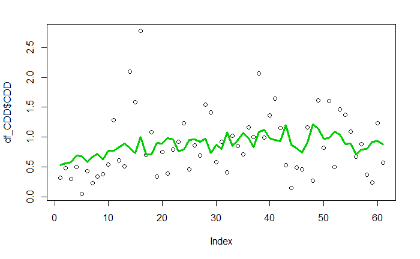

```r
md1 <-lm(CDD~time+landT+NINO3.4+PDO+SOI,data=df_CDD)
plot(df_CDD$CDD)
lines(md1$fitted.values,col=3,lwd=3)
```

```r
summary(md1)
```

```
Call:
lm(formula = CDD ~ time + landT + NINO3.4 + PDO + SOI, data = df_CDD)

Residuals:
    Min      1Q  Median      3Q     Max
-0.9450 -0.3184 -0.1328  0.3055  1.7811

Coefficients:
              Estimate Std. Error t value Pr(>|t|)
(Intercept) -22.675493  13.107855  -1.730   0.0893 .
time          0.011946   0.006647   1.797   0.0778 .
landT        -0.557707   0.336902  -1.655   0.1035
NINO3.4       0.127497   0.208962   0.610   0.5443
PDO           0.029007   0.095185   0.305   0.7617
SOI           0.003596   0.137110   0.026   0.9792
---
Signif. codes:  0 *** 0.001 ** 0.01 * 0.05 . 0.1   1

Residual standard error: 0.5413 on 55 degrees of freedom
Multiple R-squared:  0.08416,   Adjusted R-squared:  0.0009029
F-statistic: 1.011 on 5 and 55 DF,  p-value: 0.4202
```

Below is for HDD

```r
df_HDD <- as.data.frame(cbind(seas_HDD[,2],NINO4SON,NAOSON[,2],AMOSON[,2],landTSON[,2]))
df_HDD <- df_HDD[which(df_HDD[,2]<=2005),]  ##withheld year2005 and after year 2005
colnames(df_HDD) <- c("HDD","time","NINO4","NAO","AMO","landT")
md1 <-lm(HDD~NINO4,data=df_HDD)
summary(md1)
```

```
Call:
lm(formula = HDD ~ NINO4, data = df_HDD)

Residuals:
    Min      1Q  Median      3Q     Max
-1.3707 -0.5644 -0.0106  0.3970  2.9757

Coefficients:
            Estimate Std. Error t value Pr(>|t|)
(Intercept)   1.8275     0.1073  17.034  < 2e-16 ***
NINO4        -0.4496     0.1669  -2.694  0.00917 **
---
Signif. codes:  0 *** 0.001 ** 0.01 * 0.05 . 0.1   1

Residual standard error: 0.8378 on 59 degrees of freedom
Multiple R-squared:  0.1096,    Adjusted R-squared:  0.09447
F-statistic:  7.26 on 1 and 59 DF,  p-value: 0.00917
```

```r
md2 <-lm(HDD~time,data=df_HDD)
summary(md2)
```

```
Call:
lm(formula = HDD ~ time, data = df_HDD)

Residuals:
     Min       1Q   Median       3Q      Max
-1.86752 -0.51312 -0.02869  0.48328  2.37344

Coefficients:
             Estimate Std. Error t value Pr(>|t|)
(Intercept) 50.751552  11.048061   4.594 2.34e-05 ***
time        -0.024770   0.005594  -4.428 4.17e-05 ***
---
Signif. codes:  0 *** 0.001 ** 0.01 * 0.05 . 0.1   1

Residual standard error: 0.7692 on 59 degrees of freedom
Multiple R-squared:  0.2494,    Adjusted R-squared:  0.2367
F-statistic: 19.61 on 1 and 59 DF,  p-value: 4.175e-05
```

```r
md3 <-lm(HDD~NAO,data=df_HDD)
summary(md3)
```

```
Call:
lm(formula = HDD ~ NAO, data = df_HDD)

Residuals:
     Min       1Q   Median       3Q      Max
-1.50094 -0.61490 -0.08994  0.42609  2.69060

Coefficients:
            Estimate Std. Error t value Pr(>|t|)
(Intercept)   1.8675     0.1122  16.637   <2e-16 ***
NAO           0.2236     0.1204   1.857   0.0684 .
---
Signif. codes:  0 *** 0.001 ** 0.01 * 0.05 . 0.1   1

Residual standard error: 0.863 on 59 degrees of freedom
Multiple R-squared:  0.0552,    Adjusted R-squared:  0.03919
F-statistic: 3.447 on 1 and 59 DF,  p-value: 0.06836
```

```r
md4 <-lm(HDD~AMO,data=df_HDD)
summary(md4)
```

```
Call:
lm(formula = HDD ~ AMO, data = df_HDD)

Residuals:
     Min       1Q   Median       3Q      Max
-1.49716 -0.66564 -0.03647  0.65396  2.74295

Coefficients:
            Estimate Std. Error t value Pr(>|t|)
(Intercept)   1.8918     0.1125  16.813   <2e-16 ***
AMO           1.5426     0.6907   2.233   0.0293 *
---
Signif. codes:  0 *** 0.001 ** 0.01 * 0.05 . 0.1   1

Residual standard error: 0.8526 on 59 degrees of freedom
Multiple R-squared:  0.07795,   Adjusted R-squared:  0.06232
F-statistic: 4.988 on 1 and 59 DF,  p-value: 0.02933
```

```r
md5 <-lm(HDD~landT,data=df_HDD)
summary(md5)
```

```
Call:
lm(formula = HDD ~ landT, data = df_HDD)

Residuals:
     Min       1Q   Median       3Q      Max
-1.47753 -0.56320 -0.08011  0.47418  2.99458

Coefficients:
            Estimate Std. Error t value Pr(>|t|)
(Intercept)   1.8832     0.1179   15.97   <2e-16 ***
landT        -0.5481     0.3916   -1.40    0.167
---
Signif. codes:  0 *** 0.001 ** 0.01 * 0.05 . 0.1   1

Residual standard error: 0.8735 on 59 degrees of freedom
Multiple R-squared:  0.03214,   Adjusted R-squared:  0.01574
F-statistic: 1.959 on 1 and 59 DF,  p-value: 0.1668
```

The time predictor has the smallest MSE, largest R2 and the largest F ratio, so choose time as the first predictor. The remaining predictor would reduce the R2 by an amount larger than 0.05%, so we choose to continue adding predictors.

```r
md1 <- lm(HDD~time+NINO4,data=df_HDD)
md2 <- lm(HDD~time+NAO,data=df_HDD)
md3 <- lm(HDD~time+AMO,data=df_HDD)
md4 <- lm(HDD~time+landT,data=df_HDD)
summary(md1)
```

```
Call:
lm(formula = HDD ~ time + NINO4, data = df_HDD)

Residuals:
     Min       1Q   Median       3Q      Max
-1.65073 -0.46693  0.00111  0.51338  2.42358

Coefficients:
             Estimate Std. Error t value Pr(>|t|)
(Intercept) 44.985976  11.339935   3.967 0.000203 ***
time        -0.021852   0.005741  -3.806 0.000343 ***
NINO4       -0.276776   0.157229  -1.760 0.083622 .
---
Signif. codes:  0 *** 0.001 ** 0.01 * 0.05 . 0.1   1

Residual standard error: 0.7559 on 58 degrees of freedom
Multiple R-squared:  0.2875,    Adjusted R-squared:  0.2629
F-statistic:  11.7 on 2 and 58 DF,  p-value: 5.377e-05
```

```r
summary(md2)
```

```
Call:
lm(formula = HDD ~ time + NAO, data = df_HDD)

Residuals:
     Min       1Q   Median       3Q      Max
-1.80362 -0.44567 -0.05991  0.51808  2.29262

Coefficients:
             Estimate Std. Error t value Pr(>|t|)
(Intercept) 48.154821  11.714698   4.111 0.000126 ***
time        -0.023449   0.005934  -3.951 0.000213 ***
NAO          0.078791   0.113881   0.692 0.491777
---
Signif. codes:  0 *** 0.001 ** 0.01 * 0.05 . 0.1   1

Residual standard error: 0.7726 on 58 degrees of freedom
Multiple R-squared:  0.2556,    Adjusted R-squared:  0.2299
F-statistic: 9.957 on 2 and 58 DF,  p-value: 0.0001917
```

```r
summary(md3)
```

```
Call:
lm(formula = HDD ~ time + AMO, data = df_HDD)

Residuals:
     Min       1Q   Median       3Q      Max
-1.86618 -0.47614  0.00225  0.45127  2.25140

Coefficients:
             Estimate Std. Error t value Pr(>|t|)
(Intercept) 46.921011  11.203132   4.188 9.69e-05 ***
time        -0.022811   0.005675  -4.020  0.00017 ***
AMO          0.972023   0.632248   1.537  0.12963
---
Signif. codes:  0 *** 0.001 ** 0.01 * 0.05 . 0.1   1

Residual standard error: 0.7605 on 58 degrees of freedom
Multiple R-squared:  0.2788,    Adjusted R-squared:  0.254
F-statistic: 11.21 on 2 and 58 DF,  p-value: 7.638e-05
```

```r
summary(md4)
```

```
Call:
lm(formula = HDD ~ time + landT, data = df_HDD)

Residuals:
     Min       1Q   Median       3Q      Max
-1.92289 -0.43320  0.01475  0.44223  2.26498

Coefficients:
             Estimate Std. Error t value Pr(>|t|)
(Intercept) 60.614093  13.546937   4.474 3.63e-05 ***
time        -0.029789   0.006871  -4.335 5.87e-05 ***
landT        0.528046   0.423597   1.247    0.218
---
Signif. codes:  0 *** 0.001 ** 0.01 * 0.05 . 0.1   1

Residual standard error: 0.7656 on 58 degrees of freedom
Multiple R-squared:  0.269, Adjusted R-squared:  0.2438
F-statistic: 10.67 on 2 and 58 DF,  p-value: 0.000113
```

The NINO4 predictor has the smallest MSE, largest R2 and the highest F ratio this time, so choose NINO4 as the second predictor. The remaining predictor would reduce the R2 by an amount larger than 0.05%, so we choose to continue adding predictors.

```r
md1 <-lm(HDD~time+NINO4+NAO,data=df_HDD)
md2 <-lm(HDD~time+NINO4+AMO,data=df_HDD)
md3 <-lm(HDD~time+NINO4+landT,data=df_HDD)
summary(md1)
```

```
Call:
lm(formula = HDD ~ time + NINO4 + NAO, data = df_HDD)

Residuals:
    Min      1Q  Median      3Q     Max
-1.6186 -0.4209 -0.0107  0.5104  2.3703

Coefficients:
             Estimate Std. Error t value Pr(>|t|)
(Intercept) 43.562774  11.868031   3.671 0.000535 ***
time        -0.021127   0.006011  -3.515 0.000871 ***
NINO4       -0.265997   0.160213  -1.660 0.102353
NAO          0.049996   0.113527   0.440 0.661319
---
Signif. codes:  0 *** 0.001 ** 0.01 * 0.05 . 0.1   1

Residual standard error: 0.7612 on 57 degrees of freedom
Multiple R-squared:  0.2899,    Adjusted R-squared:  0.2526
F-statistic: 7.758 on 3 and 57 DF,  p-value: 0.0001976
```

```r
summary(md2)
```

```
Call:
lm(formula = HDD ~ time + NINO4 + AMO, data = df_HDD)

Residuals:
     Min       1Q   Median       3Q      Max
-1.68387 -0.59758 -0.02783  0.50659  2.32058

Coefficients:
             Estimate Std. Error t value Pr(>|t|)
(Intercept) 42.910125  11.439334   3.751 0.000414 ***
time        -0.020785   0.005794  -3.588 0.000694 ***
NINO4       -0.233137   0.161038  -1.448 0.153175
AMO          0.757440   0.643657   1.177 0.244176
---
Signif. codes:  0 *** 0.001 ** 0.01 * 0.05 . 0.1   1

Residual standard error: 0.7534 on 57 degrees of freedom
Multiple R-squared:  0.3044,    Adjusted R-squared:  0.2678
F-statistic: 8.315 on 3 and 57 DF,  p-value: 0.0001123
```

```r
summary(md3)
```

```
Call:
lm(formula = HDD ~ time + NINO4 + landT, data = df_HDD)

Residuals:
     Min       1Q   Median       3Q      Max
-1.68377 -0.51988  0.01615  0.43868  2.28937

Coefficients:
             Estimate Std. Error t value Pr(>|t|)
(Intercept) 56.965747  13.291987   4.286 7.09e-05 ***
time        -0.027951   0.006741  -4.147 0.000113 ***
NINO4       -0.328130   0.157936  -2.078 0.042260 *
landT        0.698679   0.420089   1.663 0.101768
---
Signif. codes:  0 *** 0.001 ** 0.01 * 0.05 . 0.1   1

Residual standard error: 0.7446 on 57 degrees of freedom
Multiple R-squared:  0.3205,    Adjusted R-squared:  0.2847
F-statistic: 8.961 on 3 and 57 DF,  p-value: 5.901e-05
```

The landT predictor has the smallest MSE, largest R2 and highest F ratio this time, so we choose landT as the third predictor. The remaining predictor would reduce the R2 by an amount larger than 0.05%, so we choose to continue adding predictors.

```r
md1 <-lm(HDD~time+NINO4+landT+NAO,data=df_HDD)
md2 <-lm(HDD~time+NINO4+landT+AMO,data=df_HDD)
summary(md1)
```

```
Call:
lm(formula = HDD ~ time + NINO4 + landT + NAO, data = df_HDD)

Residuals:
     Min       1Q   Median       3Q      Max
-1.64776 -0.48113  0.02601  0.45537  2.22759

Coefficients:
             Estimate Std. Error t value Pr(>|t|)
(Intercept) 55.484094  13.695718   4.051 0.000159 ***
time        -0.027197   0.006947  -3.915 0.000248 ***
NINO4       -0.316478   0.160633  -1.970 0.053768 .
landT        0.706310   0.423124   1.669 0.100645
NAO          0.056646   0.111860   0.506 0.614563
---
Signif. codes:  0 *** 0.001 ** 0.01 * 0.05 . 0.1   1

Residual standard error: 0.7495 on 56 degrees of freedom
Multiple R-squared:  0.3236,    Adjusted R-squared:  0.2753
F-statistic: 6.697 on 4 and 56 DF,  p-value: 0.0001772
```

```r
summary(md2)
```

```
Call:
lm(formula = HDD ~ time + NINO4 + landT + AMO, data = df_HDD)

Residuals:
     Min       1Q   Median       3Q      Max
-1.68408 -0.52218  0.01674  0.43798  2.28871

Coefficients:
             Estimate Std. Error t value Pr(>|t|)
(Intercept) 56.810657  16.611061   3.420  0.00117 **
time        -0.027872   0.008443  -3.301  0.00168 **
NINO4       -0.326805   0.180019  -1.815  0.07482 .
landT        0.691936   0.601077   1.151  0.25456
AMO          0.014401   0.910261   0.016  0.98743
---
Signif. codes:  0 *** 0.001 ** 0.01 * 0.05 . 0.1   1

Residual standard error: 0.7513 on 56 degrees of freedom
Multiple R-squared:  0.3205,    Adjusted R-squared:  0.272
F-statistic: 6.603 on 4 and 56 DF,  p-value: 0.0001997
```

The NAO predictor has smaller MSE, larger R2 and higher F ratio, so we choose NAO as the fourth predictor.The remaining predictor would reduce the R2 by an amount larger than 0.05%, so we choose to continue adding predictors.

```r
md1 <-lm(HDD~time+NINO4+landT+NAO+AMO,data=df_HDD)
summary(md1)
```

```
Call:
lm(formula = HDD ~ time + NINO4 + landT + NAO + AMO, data = df_HDD)

Residuals:
     Min       1Q   Median       3Q      Max
-1.64818 -0.49922  0.01389  0.45947  2.21760

Coefficients:
             Estimate Std. Error t value Pr(>|t|)
(Intercept) 53.997583  17.573573   3.073  0.00330 **
time        -0.026438   0.008934  -2.959  0.00454 **
NINO4       -0.303841   0.186506  -1.629  0.10900
landT        0.646403   0.611333   1.057  0.29497
NAO          0.060362   0.116071   0.520  0.60512
AMO          0.129007   0.942380   0.137  0.89161
---
Signif. codes:  0 *** 0.001 ** 0.01 * 0.05 . 0.1   1

Residual standard error: 0.7562 on 55 degrees of freedom
Multiple R-squared:  0.3238,    Adjusted R-squared:  0.2623
F-statistic: 5.268 on 5 and 55 DF,  p-value: 0.000505
```

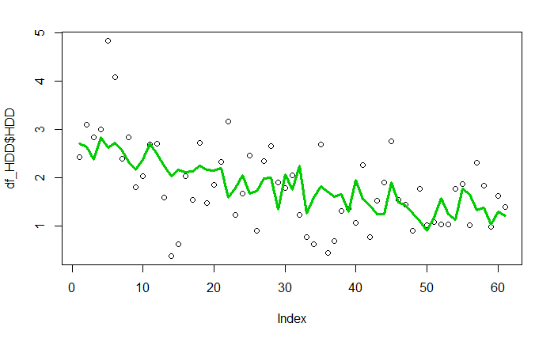

```r
plot(df_HDD$HDD)
lines(md1$fitted.values,col=3,lwd=3)
```

```r
summary(md1)
```

```
Call:
lm(formula = HDD ~ time + NINO4 + landT + NAO + AMO, data = df_HDD)

Residuals:
     Min       1Q   Median       3Q      Max
-1.64818 -0.49922  0.01389  0.45947  2.21760

Coefficients:
             Estimate Std. Error t value Pr(>|t|)
(Intercept) 53.997583  17.573573   3.073  0.00330 **
time        -0.026438   0.008934  -2.959  0.00454 **
NINO4       -0.303841   0.186506  -1.629  0.10900
landT        0.646403   0.611333   1.057  0.29497
NAO          0.060362   0.116071   0.520  0.60512
AMO          0.129007   0.942380   0.137  0.89161
---
Signif. codes:  0 *** 0.001 ** 0.01 * 0.05 . 0.1   1

Residual standard error: 0.7562 on 55 degrees of freedom
Multiple R-squared:  0.3238,    Adjusted R-squared:  0.2623
F-statistic: 5.268 on 5 and 55 DF,  p-value: 0.000505
```

```r
###Add MAM average Tmin, MAM average Tmax in Los Angeles to CDD predictor, and SON average Tmin, SON average Tmax in Los Angeles to HDD predictor
getMAM <- function(index){
  tmp=index[which((index[,2]==3)|(index[,2]==4)|(index[,2]==5)),]
  l=length(unique(tmp[,1]))
  out=rep(0,l)
  for(i in 1:l){
    out[i]=mean(tmp[which(tmp[,1]==unique(tmp[,1])[i]),3])
  }
  out1 <- cbind(unique(tmp[,1]),out)
  return(out1)
}
getSON <- function(index){
  index=index[which(index[,3]!=-999.9),]
  tmp=index[which((index[,2]==9)|(index[,2]==10)|(index[,2]==11)),]
  l=length(unique(tmp[,1]))-1
  out=rep(0,l)
  for(i in 1:l){
    out[i]=mean(tmp[which(tmp[,1]==unique(tmp[,1])[i]),3])
  }
  out1 <- cbind(unique(tmp[,1])[2:(l+1)],out)
  return(out1)
}
Tmin_MAM=getMAM(Tmin[c(1,2,5)])
Tmax_MAM=getMAM(Tmax[c(1,2,5)])
Tmin_SON=getSON(Tmin[c(1,2,5)])
Tmax_SON=getSON(Tmax[c(1,2,5)])
```

Do the stepwise again for both CDD and HDD ###For CDD###

```r
df_CDD <- as.data.frame(cbind(seas_CDD[,2],NINO3.4MAM,SOIMAM[,2],PDOMAM[,2],landTMAM[,2],Tmin_MAM[,2],Tmax_MAM[,2]))
df_CDD <- df_CDD[which(df_CDD[,2]<=2005),]  ##withheld year2005 and after year 2005
colnames(df_CDD) <- c("CDD","time","NINO3.4","SOI","PDO","landT","Tmin","Tmax")
md1 <-lm(CDD~NINO3.4,data=df_CDD)
summary(md1)
```

```
Call:
lm(formula = CDD ~ NINO3.4, data = df_CDD)

Residuals:
    Min      1Q  Median      3Q     Max
-0.8123 -0.4259 -0.0708  0.3261  1.9044

Coefficients:
            Estimate Std. Error t value Pr(>|t|)
(Intercept)  0.87074    0.06946  12.535   <2e-16 ***
NINO3.4      0.11720    0.12140   0.965    0.338
---
Signif. codes:  0 *** 0.001 ** 0.01 * 0.05 . 0.1   1

Residual standard error: 0.5419 on 59 degrees of freedom
Multiple R-squared:  0.01555,   Adjusted R-squared:  -0.001135
F-statistic: 0.932 on 1 and 59 DF,  p-value: 0.3383
```

```r
md2 <-lm(CDD~time,data=df_CDD)
summary(md2)
```

```
Call:
lm(formula = CDD ~ time, data = df_CDD)

Residuals:
    Min      1Q  Median      3Q     Max
-0.7895 -0.3997 -0.1158  0.2706  1.9905

Coefficients:
             Estimate Std. Error t value Pr(>|t|)
(Intercept) -8.988194   7.738687  -1.161    0.250
time         0.004990   0.003918   1.274    0.208

Residual standard error: 0.5388 on 59 degrees of freedom
Multiple R-squared:  0.02676,   Adjusted R-squared:  0.01026
F-statistic: 1.622 on 1 and 59 DF,  p-value: 0.2078
```

```r
md3 <-lm(CDD~SOI,data=df_CDD)
summary(md3)
```

```
Call:
lm(formula = CDD ~ SOI, data = df_CDD)

Residuals:
    Min      1Q  Median      3Q     Max
-0.8049 -0.4141 -0.1236  0.2951  1.9551

Coefficients:
            Estimate Std. Error t value Pr(>|t|)
(Intercept)  0.85601    0.07159  11.958   <2e-16 ***
SOI         -0.05356    0.07703  -0.695     0.49
---
Signif. codes:  0 *** 0.001 ** 0.01 * 0.05 . 0.1   1

Residual standard error: 0.5439 on 59 degrees of freedom
Multiple R-squared:  0.008128,  Adjusted R-squared:  -0.008684
F-statistic: 0.4835 on 1 and 59 DF,  p-value: 0.4896
```

```r
md4 <-lm(CDD~PDO,data=df_CDD)
summary(md4)
```

```
Call:
lm(formula = CDD ~ PDO, data = df_CDD)

Residuals:
    Min      1Q  Median      3Q     Max
-0.8079 -0.3978 -0.1044  0.3201  1.9010

Coefficients:
            Estimate Std. Error t value Pr(>|t|)
(Intercept)  0.86261    0.06939  12.431   <2e-16 ***
PDO          0.07432    0.06865   1.083    0.283
---
Signif. codes:  0 *** 0.001 ** 0.01 * 0.05 . 0.1   1

Residual standard error: 0.5408 on 59 degrees of freedom
Multiple R-squared:  0.01948,   Adjusted R-squared:  0.002859
F-statistic: 1.172 on 1 and 59 DF,  p-value: 0.2834
```

```r
md5 <-lm(CDD~landT,data=df_CDD)
summary(md5)
```

```
Call:
lm(formula = CDD ~ landT, data = df_CDD)

Residuals:
    Min      1Q  Median      3Q     Max
-0.8133 -0.4041 -0.1089  0.2952  1.9244

Coefficients:
            Estimate Std. Error t value Pr(>|t|)
(Intercept)  0.86608    0.07207  12.017   <2e-16 ***
landT        0.01663    0.20158   0.082    0.935
---
Signif. codes:  0 *** 0.001 ** 0.01 * 0.05 . 0.1   1

Residual standard error: 0.5461 on 59 degrees of freedom
Multiple R-squared:  0.0001153, Adjusted R-squared:  -0.01683
F-statistic: 0.006803 on 1 and 59 DF,  p-value: 0.9345
```

```r
md6 <-lm(CDD~Tmin,data=df_CDD)
summary(md6)
```

```
Call:
lm(formula = CDD ~ Tmin, data = df_CDD)

Residuals:
     Min       1Q   Median       3Q      Max
-0.99436 -0.37661 -0.07242  0.30376  1.91688

Coefficients:
            Estimate Std. Error t value Pr(>|t|)
(Intercept) -0.93449    0.77939  -1.199   0.2353
Tmin         0.15306    0.06595   2.321   0.0238 *
---
Signif. codes:  0 *** 0.001 ** 0.01 * 0.05 . 0.1   1

Residual standard error: 0.5228 on 59 degrees of freedom
Multiple R-squared:  0.08364,   Adjusted R-squared:  0.06811
F-statistic: 5.386 on 1 and 59 DF,  p-value: 0.02378
```

```r
md7 <-lm(CDD~Tmax,data=df_CDD)
summary(md7)
```

```
Call:
lm(formula = CDD ~ Tmax, data = df_CDD)

Residuals:
     Min       1Q   Median       3Q      Max
-0.95818 -0.37238 -0.08566  0.31508  1.81901

Coefficients:
            Estimate Std. Error t value Pr(>|t|)
(Intercept) -1.96714    1.25804  -1.564   0.1232
Tmax         0.14451    0.06404   2.256   0.0278 *
---
Signif. codes:  0 *** 0.001 ** 0.01 * 0.05 . 0.1   1

Residual standard error: 0.524 on 59 degrees of freedom
Multiple R-squared:  0.07944,   Adjusted R-squared:  0.06384
F-statistic: 5.092 on 1 and 59 DF,  p-value: 0.02776
```

The Tmin predictor has the smallest MSE, largest R2 and the largest F ratio, so choose Tmin as the first predictor. The remaining predictor would reduce the R2 by an amount larger than 0.05%, so we choose to continue adding predictors.

```r
md1 <-lm(CDD~Tmin+NINO3.4,data=df_CDD)
md2 <-lm(CDD~Tmin+time,data=df_CDD)
md3 <-lm(CDD~Tmin+SOI,data=df_CDD)
md4 <-lm(CDD~Tmin+PDO,data=df_CDD)
md5 <-lm(CDD~Tmin+landT,data=df_CDD)
md6 <-lm(CDD~Tmin+Tmax,data=df_CDD)
summary(md1)
```

```
Call:
lm(formula = CDD ~ Tmin + NINO3.4, data = df_CDD)

Residuals:
     Min       1Q   Median       3Q      Max
-1.03788 -0.38751 -0.07086  0.30487  1.91294

Coefficients:
            Estimate Std. Error t value Pr(>|t|)
(Intercept) -0.85391    0.82248  -1.038   0.3035
Tmin         0.14631    0.06954   2.104   0.0397 *
NINO3.4      0.04072    0.12349   0.330   0.7428
---
Signif. codes:  0 *** 0.001 ** 0.01 * 0.05 . 0.1   1

Residual standard error: 0.5268 on 58 degrees of freedom
Multiple R-squared:  0.08536,   Adjusted R-squared:  0.05382
F-statistic: 2.706 on 2 and 58 DF,  p-value: 0.07521
```

```r
summary(md2)
```

```
Call:
lm(formula = CDD ~ Tmin + time, data = df_CDD)

Residuals:
     Min       1Q   Median       3Q      Max
-0.99772 -0.37773 -0.07132  0.30253  1.91171

Coefficients:
              Estimate Std. Error t value Pr(>|t|)
(Intercept) -0.2916917  8.8501515  -0.033   0.9738
Tmin         0.1566137  0.0824707   1.899   0.0625 .
time        -0.0003467  0.0047540  -0.073   0.9421
---
Signif. codes:  0 *** 0.001 ** 0.01 * 0.05 . 0.1   1

Residual standard error: 0.5273 on 58 degrees of freedom
Multiple R-squared:  0.08373,   Adjusted R-squared:  0.05213
F-statistic:  2.65 on 2 and 58 DF,  p-value: 0.07919
```

```r
summary(md3)
```

```
Call:
lm(formula = CDD ~ Tmin + SOI, data = df_CDD)

Residuals:
     Min       1Q   Median       3Q      Max
-1.01135 -0.38191 -0.06695  0.30021  1.93048

Coefficients:
            Estimate Std. Error t value Pr(>|t|)
(Intercept) -0.89796    0.79999  -1.122   0.2663
Tmin         0.14962    0.06798   2.201   0.0317 *
SOI         -0.01851    0.07632  -0.243   0.8092
---
Signif. codes:  0 *** 0.001 ** 0.01 * 0.05 . 0.1   1

Residual standard error: 0.527 on 58 degrees of freedom
Multiple R-squared:  0.08457,   Adjusted R-squared:  0.05301
F-statistic: 2.679 on 2 and 58 DF,  p-value: 0.07711
```

```r
summary(md4)
```

```
Call:
lm(formula = CDD ~ Tmin + PDO, data = df_CDD)

Residuals:
     Min       1Q   Median       3Q      Max
-0.99790 -0.37432 -0.08326  0.31062  1.91854

Coefficients:
             Estimate Std. Error t value Pr(>|t|)
(Intercept) -0.984455   0.917683  -1.073   0.2878
Tmin         0.157349   0.077963   2.018   0.0482 *
PDO         -0.008275   0.078452  -0.105   0.9164
---
Signif. codes:  0 *** 0.001 ** 0.01 * 0.05 . 0.1   1

Residual standard error: 0.5273 on 58 degrees of freedom
Multiple R-squared:  0.08382,   Adjusted R-squared:  0.05223
F-statistic: 2.653 on 2 and 58 DF,  p-value: 0.07897
```

```r
summary(md5)
```

```
Call:
lm(formula = CDD ~ Tmin + landT, data = df_CDD)

Residuals:
    Min      1Q  Median      3Q     Max
-1.0274 -0.3656 -0.1069  0.3038  1.8299

Coefficients:
            Estimate Std. Error t value Pr(>|t|)
(Intercept)  -1.1601     0.8311  -1.396   0.1681
Tmin          0.1734     0.0709   2.446   0.0175 *
landT        -0.1658     0.2074  -0.799   0.4273
---
Signif. codes:  0 *** 0.001 ** 0.01 * 0.05 . 0.1   1

Residual standard error: 0.5244 on 58 degrees of freedom
Multiple R-squared:  0.09363,   Adjusted R-squared:  0.06238
F-statistic: 2.996 on 2 and 58 DF,  p-value: 0.05778
```

```r
summary(md6)
```

```
Call:
lm(formula = CDD ~ Tmin + Tmax, data = df_CDD)

Residuals:
    Min      1Q  Median      3Q     Max
-0.9262 -0.3545 -0.1095  0.2826  1.8655

Coefficients:
            Estimate Std. Error t value Pr(>|t|)
(Intercept) -1.73453    1.28323  -1.352    0.182
Tmin         0.09415    0.09996   0.942    0.350
Tmax         0.07615    0.09684   0.786    0.435

Residual standard error: 0.5245 on 58 degrees of freedom
Multiple R-squared:  0.09331,   Adjusted R-squared:  0.06204
F-statistic: 2.984 on 2 and 58 DF,  p-value: 0.05839
```

The landT predictor has the smallest MSE, largest R2 and the largest F ratio, so choose landT as the first predictor. The remaining predictor would reduce the R2 by an amount larger than 0.05%, so we choose to continue adding predictors.

```r
md1 <-lm(CDD~Tmin+landT+NINO3.4,data=df_CDD)
md2 <-lm(CDD~Tmin+landT+time,data=df_CDD)
md3 <-lm(CDD~Tmin+landT+SOI,data=df_CDD)
md4 <-lm(CDD~Tmin+landT+PDO,data=df_CDD)
md5 <-lm(CDD~Tmin+landT+Tmax,data=df_CDD)
summary(md1)
```

```
Call:
lm(formula = CDD ~ Tmin + landT + NINO3.4, data = df_CDD)

Residuals:
     Min       1Q   Median       3Q      Max
-1.09961 -0.38253 -0.09194  0.31006  1.81218

Coefficients:
            Estimate Std. Error t value Pr(>|t|)
(Intercept) -1.06426    0.85801  -1.240   0.2199
Tmin         0.16561    0.07304   2.267   0.0272 *
landT       -0.18783    0.21333  -0.880   0.3823
NINO3.4      0.06353    0.12641   0.503   0.6172
---
Signif. codes:  0 *** 0.001 ** 0.01 * 0.05 . 0.1   1

Residual standard error: 0.5278 on 57 degrees of freedom
Multiple R-squared:  0.09763,   Adjusted R-squared:  0.05014
F-statistic: 2.056 on 3 and 57 DF,  p-value: 0.1163
```

```r
summary(md2)
```

```
Call:
lm(formula = CDD ~ Tmin + landT + time, data = df_CDD)

Residuals:
     Min       1Q   Median       3Q      Max
-1.00948 -0.36471 -0.06752  0.28552  1.81590

Coefficients:
              Estimate Std. Error t value Pr(>|t|)
(Intercept) -12.124711  13.714401  -0.884    0.380
Tmin          0.137676   0.083975   1.639    0.107
landT        -0.356587   0.316237  -1.128    0.264
time          0.005773   0.007208   0.801    0.426

Residual standard error: 0.5261 on 57 degrees of freedom
Multiple R-squared:  0.1037,    Adjusted R-squared:  0.05655
F-statistic: 2.199 on 3 and 57 DF,  p-value: 0.09808
```

```r
summary(md3)
```

```
Call:
lm(formula = CDD ~ Tmin + landT + SOI, data = df_CDD)

Residuals:
     Min       1Q   Median       3Q      Max
-1.07563 -0.36856 -0.06854  0.28693  1.84098

Coefficients:
            Estimate Std. Error t value Pr(>|t|)
(Intercept) -1.12828    0.83833  -1.346   0.1837
Tmin         0.17024    0.07158   2.378   0.0208 *
landT       -0.20612    0.22161  -0.930   0.3562
SOI         -0.04386    0.08113  -0.541   0.5908
---
Signif. codes:  0 *** 0.001 ** 0.01 * 0.05 . 0.1   1

Residual standard error: 0.5277 on 57 degrees of freedom
Multiple R-squared:  0.09826,   Adjusted R-squared:  0.0508
F-statistic:  2.07 on 3 and 57 DF,  p-value: 0.1143
```

```r
summary(md4)
```

```
Call:
lm(formula = CDD ~ Tmin + landT + PDO, data = df_CDD)

Residuals:
    Min      1Q  Median      3Q     Max
-1.0228 -0.3553 -0.1156  0.2932  1.8115

Coefficients:
            Estimate Std. Error t value Pr(>|t|)
(Intercept) -1.05774    0.92441  -1.144   0.2573
Tmin         0.16481    0.07869   2.094   0.0407 *
landT       -0.19203    0.23175  -0.829   0.4108
PDO          0.02285    0.08717   0.262   0.7942
---
Signif. codes:  0 *** 0.001 ** 0.01 * 0.05 . 0.1   1

Residual standard error: 0.5287 on 57 degrees of freedom
Multiple R-squared:  0.09472,   Adjusted R-squared:  0.04708
F-statistic: 1.988 on 3 and 57 DF,  p-value: 0.126
```

```r
summary(md5)
```

```
Call:
lm(formula = CDD ~ Tmin + landT + Tmax, data = df_CDD)

Residuals:
    Min      1Q  Median      3Q     Max
-0.9681 -0.3585 -0.1011  0.2822  1.8111

Coefficients:
            Estimate Std. Error t value Pr(>|t|)
(Intercept) -1.71335    1.29115  -1.327    0.190
Tmin         0.12413    0.11304   1.098    0.277
landT       -0.12742    0.21959  -0.580    0.564
Tmax         0.05763    0.10249   0.562    0.576

Residual standard error: 0.5275 on 57 degrees of freedom
Multiple R-squared:  0.09863,   Adjusted R-squared:  0.05119
F-statistic: 2.079 on 3 and 57 DF,  p-value: 0.1131
```

The time predictor has the smallest MSE, largest R2 and the largest F ratio, so choose time as the first predictor. The remaining predictor would reduce the R2 by an amount larger than 0.05%, so we choose to continue adding predictors.

```r
md1 <-lm(CDD~Tmin+landT+time+NINO3.4,data=df_CDD)
md2 <-lm(CDD~Tmin+landT+time+SOI,data=df_CDD)
md3 <-lm(CDD~Tmin+landT+time+PDO,data=df_CDD)
md4 <-lm(CDD~Tmin+landT+time+Tmax,data=df_CDD)
summary(md1)
```

```
Call:
lm(formula = CDD ~ Tmin + landT + time + NINO3.4, data = df_CDD)

Residuals:
     Min       1Q   Median       3Q      Max
-1.10917 -0.34199 -0.05816  0.30687  1.78780

Coefficients:
              Estimate Std. Error t value Pr(>|t|)
(Intercept) -14.208598  14.094820  -1.008    0.318
Tmin          0.119237   0.088378   1.349    0.183
landT        -0.426636   0.333079  -1.281    0.206
time          0.006943   0.007431   0.934    0.354
NINO3.4       0.090839   0.129885   0.699    0.487

Residual standard error: 0.5284 on 56 degrees of freedom
Multiple R-squared:  0.1115,    Adjusted R-squared:  0.04802
F-statistic: 1.757 on 4 and 56 DF,  p-value: 0.1506
```

```r
summary(md2)
```

```
Call:
lm(formula = CDD ~ Tmin + landT + time + SOI, data = df_CDD)

Residuals:
     Min       1Q   Median       3Q      Max
-1.06844 -0.32019 -0.07445  0.28418  1.82811

Coefficients:
              Estimate Std. Error t value Pr(>|t|)
(Intercept) -13.618444  13.954788  -0.976    0.333
Tmin          0.128589   0.085433   1.505    0.138
landT        -0.434544   0.337902  -1.286    0.204
time          0.006581   0.007340   0.897    0.374
SOI          -0.055850   0.082359  -0.678    0.500

Residual standard error: 0.5286 on 56 degrees of freedom
Multiple R-squared:  0.111, Adjusted R-squared:  0.04752
F-statistic: 1.748 on 4 and 56 DF,  p-value: 0.1523
```

```r
summary(md3)
```

```
Call:
lm(formula = CDD ~ Tmin + landT + time + PDO, data = df_CDD)

Residuals:
    Min      1Q  Median      3Q     Max
-1.0054 -0.3577 -0.0826  0.2748  1.7991

Coefficients:
              Estimate Std. Error t value Pr(>|t|)
(Intercept) -11.943122  13.849784  -0.862    0.392
Tmin          0.130017   0.090472   1.437    0.156
landT        -0.379165   0.332424  -1.141    0.259
time          0.005727   0.007271   0.788    0.434
PDO           0.021036   0.087495   0.240    0.811

Residual standard error: 0.5305 on 56 degrees of freedom
Multiple R-squared:  0.1046,    Adjusted R-squared:  0.04069
F-statistic: 1.636 on 4 and 56 DF,  p-value: 0.1779
```

```r
summary(md4)
```

```
Call:
lm(formula = CDD ~ Tmin + landT + time + Tmax, data = df_CDD)

Residuals:
     Min       1Q   Median       3Q      Max
-0.92220 -0.34114 -0.07437  0.24366  1.77546

Coefficients:
              Estimate Std. Error t value Pr(>|t|)
(Intercept) -18.403126  15.273942  -1.205    0.233
Tmin          0.031676   0.140854   0.225    0.823
landT        -0.379288   0.317495  -1.195    0.237
time          0.008555   0.007801   1.097    0.278
Tmax          0.103748   0.110617   0.938    0.352

Residual standard error: 0.5266 on 56 degrees of freedom
Multiple R-squared:  0.1176,    Adjusted R-squared:  0.05455
F-statistic: 1.866 on 4 and 56 DF,  p-value: 0.1293
```

The Tmax predictor has the smallest MSE, largest R2 and the largest F ratio, so choose Tmax as the first predictor. The remaining predictor would reduce the R2 by an amount larger than 0.05%, so we choose to continue adding predictors.

```r
md1 <-lm(CDD~Tmin+landT+time+Tmax+NINO3.4,data=df_CDD)
md2 <-lm(CDD~Tmin+landT+time+Tmax+SOI,data=df_CDD)
md3 <-lm(CDD~Tmin+landT+time+Tmax+PDO,data=df_CDD)
summary(md1)
```

```
Call:
lm(formula = CDD ~ Tmin + landT + time + Tmax + NINO3.4, data = df_CDD)

Residuals:
    Min      1Q  Median      3Q     Max
-0.9975 -0.3158 -0.1049  0.2916  1.7416

Coefficients:
              Estimate Std. Error t value Pr(>|t|)
(Intercept) -21.126420  15.726739  -1.343    0.185
Tmin          0.004303   0.145709   0.030    0.977
landT        -0.458599   0.334679  -1.370    0.176
time          0.010035   0.008059   1.245    0.218
Tmax          0.110486   0.111354   0.992    0.325
NINO3.4       0.100937   0.130301   0.775    0.442

Residual standard error: 0.5285 on 55 degrees of freedom
Multiple R-squared:  0.1271,    Adjusted R-squared:  0.04775
F-statistic: 1.602 on 5 and 55 DF,  p-value: 0.175
```

```r
summary(md2)
```

```
Call:
lm(formula = CDD ~ Tmin + landT + time + Tmax + SOI, data = df_CDD)

Residuals:
     Min       1Q   Median       3Q      Max
-0.95292 -0.29849 -0.08199  0.27112  1.78703

Coefficients:
              Estimate Std. Error t value Pr(>|t|)
(Intercept) -20.217480  15.544619  -1.301    0.199
Tmin          0.018232   0.142683   0.128    0.899
landT        -0.463156   0.339399  -1.365    0.178
time          0.009514   0.007947   1.197    0.236
Tmax          0.107430   0.111211   0.966    0.338
SOI          -0.059508   0.082495  -0.721    0.474

Residual standard error: 0.5289 on 55 degrees of freedom
Multiple R-squared:  0.1259,    Adjusted R-squared:  0.04639
F-statistic: 1.584 on 5 and 55 DF,  p-value: 0.18
```

```r
summary(md3)
```

```
Call:
lm(formula = CDD ~ Tmin + landT + time + Tmax + PDO, data = df_CDD)

Residuals:
     Min       1Q   Median       3Q      Max
-0.92275 -0.33755 -0.07568  0.24458  1.77369

Coefficients:
              Estimate Std. Error t value Pr(>|t|)
(Intercept) -18.335242  15.591593  -1.176    0.245
Tmin          0.031501   0.142256   0.221    0.826
landT        -0.381904   0.333012  -1.147    0.256
time          0.008529   0.007923   1.077    0.286
Tmax          0.102996   0.114638   0.898    0.373
PDO           0.002590   0.090018   0.029    0.977

Residual standard error: 0.5314 on 55 degrees of freedom
Multiple R-squared:  0.1176,    Adjusted R-squared:  0.03738
F-statistic: 1.466 on 5 and 55 DF,  p-value: 0.2159
```

The NINO3.4 predictor has the smallest MSE, largest R2 and the largest F ratio, so choose NINO3.4 as the first predictor. The remaining predictor would reduce the R2 by an amount larger than 0.05%, so we choose to continue adding predictors.

```r
md1 <-lm(CDD~Tmin+landT+time+Tmax+NINO3.4+SOI,data=df_CDD)
md2 <-lm(CDD~Tmin+landT+time+Tmax+NINO3.4+PDO,data=df_CDD)
summary(md1)
```

```
Call:
lm(formula = CDD ~ Tmin + landT + time + Tmax + NINO3.4 + SOI,
    data = df_CDD)

Residuals:
     Min       1Q   Median       3Q      Max
-0.99057 -0.31034 -0.09889  0.27998  1.75654

Coefficients:
              Estimate Std. Error t value Pr(>|t|)
(Intercept) -21.053715  15.871815  -1.326    0.190
Tmin          0.007004   0.147751   0.047    0.962
landT        -0.469236   0.342663  -1.369    0.177
time          0.009984   0.008135   1.227    0.225
Tmax          0.109974   0.112381   0.979    0.332
NINO3.4       0.070599   0.212053   0.333    0.740
SOI          -0.024462   0.134157  -0.182    0.856

Residual standard error: 0.5332 on 54 degrees of freedom
Multiple R-squared:  0.1276,    Adjusted R-squared:  0.03072
F-statistic: 1.317 on 6 and 54 DF,  p-value: 0.2656
```

```r
summary(md2)
```

```
Call:
lm(formula = CDD ~ Tmin + landT + time + Tmax + NINO3.4 + PDO,
    data = df_CDD)

Residuals:
     Min       1Q   Median       3Q      Max
-1.01330 -0.34168 -0.09456  0.28946  1.75700

Coefficients:
              Estimate Std. Error t value Pr(>|t|)
(Intercept) -22.494010  16.413326  -1.370    0.176
Tmin          0.001164   0.147232   0.008    0.994
landT        -0.441570   0.341543  -1.293    0.202
time          0.010641   0.008340   1.276    0.207
Tmax          0.121104   0.116997   1.035    0.305
NINO3.4       0.120476   0.144664   0.833    0.409
PDO          -0.032067   0.099401  -0.323    0.748

Residual standard error: 0.5329 on 54 degrees of freedom
Multiple R-squared:  0.1288,    Adjusted R-squared:  0.03198
F-statistic:  1.33 on 6 and 54 DF,  p-value: 0.2598
```

The PDO predictor has the smallest MSE, largest R2 and the largest F ratio, so choose PDO as the first predictor. The remaining predictor would reduce the R2 by an amount larger than 0.05%, so we choose to continue to add predictors.

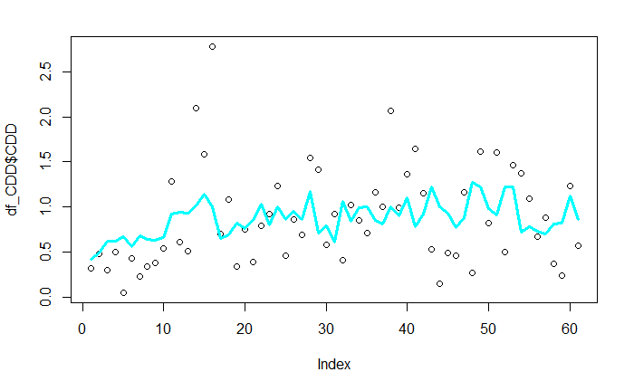

```r
md1 <-lm(CDD~Tmin+landT+time+Tmax+NINO3.4+SOI+PDO,data=df_CDD)
plot(df_CDD$CDD)
lines(md1$fitted.values,col=5,lwd=3)
```

```r
mdCDD <- md1
```

### For HDD

```r
df_HDD <- as.data.frame(cbind(seas_HDD[,2],NINO4SON,NAOSON[,2],AMOSON[,2],landTSON[,2],Tmin_SON[,2],Tmax_SON[,2]))
df_HDD <- df_HDD[which(df_HDD[,2]<=2005),]  ##withheld year2005 and after year 2005
colnames(df_HDD) <- c("HDD","time","NINO4","NAO","AMO","landT","Tmin","Tmax")
md1 <-lm(HDD~time,data=df_HDD)
md2 <-lm(HDD~NINO4,data=df_HDD)
md3 <-lm(HDD~NAO,data=df_HDD)
md4 <-lm(HDD~AMO,data=df_HDD)
md5 <-lm(HDD~landT,data=df_HDD)
md6 <-lm(HDD~Tmin,data=df_HDD)
md7 <-lm(HDD~Tmax,data=df_HDD)
summary(md1)
```

```
Call:
lm(formula = HDD ~ time, data = df_HDD)

Residuals:
     Min       1Q   Median       3Q      Max
-1.86752 -0.51312 -0.02869  0.48328  2.37344

Coefficients:
             Estimate Std. Error t value Pr(>|t|)
(Intercept) 50.751552  11.048061   4.594 2.34e-05 ***
time        -0.024770   0.005594  -4.428 4.17e-05 ***
---
Signif. codes:  0 *** 0.001 ** 0.01 * 0.05 . 0.1   1

Residual standard error: 0.7692 on 59 degrees of freedom
Multiple R-squared:  0.2494,    Adjusted R-squared:  0.2367
F-statistic: 19.61 on 1 and 59 DF,  p-value: 4.175e-05
```

```r
summary(md2)
```

```
Call:
lm(formula = HDD ~ NINO4, data = df_HDD)

Residuals:
    Min      1Q  Median      3Q     Max
-1.3707 -0.5644 -0.0106  0.3970  2.9757

Coefficients:
            Estimate Std. Error t value Pr(>|t|)
(Intercept)   1.8275     0.1073  17.034  < 2e-16 ***
NINO4        -0.4496     0.1669  -2.694  0.00917 **
---
Signif. codes:  0 *** 0.001 ** 0.01 * 0.05 . 0.1   1

Residual standard error: 0.8378 on 59 degrees of freedom
Multiple R-squared:  0.1096,    Adjusted R-squared:  0.09447
F-statistic:  7.26 on 1 and 59 DF,  p-value: 0.00917
```

```r
summary(md3)
```

```
Call:
lm(formula = HDD ~ NAO, data = df_HDD)

Residuals:
     Min       1Q   Median       3Q      Max
-1.50094 -0.61490 -0.08994  0.42609  2.69060

Coefficients:
            Estimate Std. Error t value Pr(>|t|)
(Intercept)   1.8675     0.1122  16.637   <2e-16 ***
NAO           0.2236     0.1204   1.857   0.0684 .
---
Signif. codes:  0 *** 0.001 ** 0.01 * 0.05 . 0.1   1

Residual standard error: 0.863 on 59 degrees of freedom
Multiple R-squared:  0.0552,    Adjusted R-squared:  0.03919
F-statistic: 3.447 on 1 and 59 DF,  p-value: 0.06836
```

```r
summary(md4)
```

```
Call:
lm(formula = HDD ~ AMO, data = df_HDD)

Residuals:
     Min       1Q   Median       3Q      Max
-1.49716 -0.66564 -0.03647  0.65396  2.74295

Coefficients:
            Estimate Std. Error t value Pr(>|t|)
(Intercept)   1.8918     0.1125  16.813   <2e-16 ***
AMO           1.5426     0.6907   2.233   0.0293 *
---
Signif. codes:  0 *** 0.001 ** 0.01 * 0.05 . 0.1   1

Residual standard error: 0.8526 on 59 degrees of freedom
Multiple R-squared:  0.07795,   Adjusted R-squared:  0.06232
F-statistic: 4.988 on 1 and 59 DF,  p-value: 0.02933
```

```r
summary(md5)
```

```
Call:
lm(formula = HDD ~ landT, data = df_HDD)

Residuals:
     Min       1Q   Median       3Q      Max
-1.47753 -0.56320 -0.08011  0.47418  2.99458

Coefficients:
            Estimate Std. Error t value Pr(>|t|)
(Intercept)   1.8832     0.1179   15.97   <2e-16 ***
landT        -0.5481     0.3916   -1.40    0.167
---
Signif. codes:  0 *** 0.001 ** 0.01 * 0.05 . 0.1   1

Residual standard error: 0.8735 on 59 degrees of freedom
Multiple R-squared:  0.03214,   Adjusted R-squared:  0.01574
F-statistic: 1.959 on 1 and 59 DF,  p-value: 0.1668
```

```r
summary(md6)
```

```
Call:
lm(formula = HDD ~ Tmin, data = df_HDD)

Residuals:
     Min       1Q   Median       3Q      Max
-1.68847 -0.50675 -0.04487  0.43691  1.78136

Coefficients:
            Estimate Std. Error t value Pr(>|t|)
(Intercept)  8.69298    1.25755   6.913 3.80e-09 ***
Tmin        -0.47964    0.08766  -5.472 9.55e-07 ***
---
Signif. codes:  0 *** 0.001 ** 0.01 * 0.05 . 0.1   1

Residual standard error: 0.7232 on 59 degrees of freedom
Multiple R-squared:  0.3366,    Adjusted R-squared:  0.3254
F-statistic: 29.94 on 1 and 59 DF,  p-value: 9.552e-07
```

```r
summary(md7)
```

```
Call:
lm(formula = HDD ~ Tmax, data = df_HDD)

Residuals:
     Min       1Q   Median       3Q      Max
-1.45596 -0.59752 -0.02147  0.45730  2.84176

Coefficients:
            Estimate Std. Error t value Pr(>|t|)
(Intercept)   7.5218     2.3806   3.160  0.00249 **
Tmax         -0.2479     0.1036  -2.393  0.01991 *
---
Signif. codes:  0 *** 0.001 ** 0.01 * 0.05 . 0.1   1

Residual standard error: 0.8477 on 59 degrees of freedom
Multiple R-squared:  0.08847,   Adjusted R-squared:  0.07302
F-statistic: 5.726 on 1 and 59 DF,  p-value: 0.01991
```

The Tmin predictor has the smallest MSE, largest R2 and the largest F ratio, so choose Tmin as the first predictor. The remaining predictor would reduce the R2 by an amount larger than 0.05%, so we choose to continue adding predictors.

```r
md1 <-lm(HDD~Tmin+time,data=df_HDD)
md2 <-lm(HDD~Tmin+NINO4,data=df_HDD)
md3 <-lm(HDD~Tmin+NAO,data=df_HDD)
md4 <-lm(HDD~Tmin+AMO,data=df_HDD)
md5 <-lm(HDD~Tmin+landT,data=df_HDD)
md6 <-lm(HDD~Tmin+Tmax,data=df_HDD)
summary(md1)
```

```
Call:
lm(formula = HDD ~ Tmin + time, data = df_HDD)

Residuals:
     Min       1Q   Median       3Q      Max
-1.84200 -0.48836 -0.03976  0.44474  1.75913

Coefficients:
             Estimate Std. Error t value Pr(>|t|)
(Intercept) 31.749171  11.492471   2.763  0.00767 **
Tmin        -0.361882   0.103490  -3.497  0.00091 ***
time        -0.012527   0.006209  -2.018  0.04826 *
---
Signif. codes:  0 *** 0.001 ** 0.01 * 0.05 . 0.1   1

Residual standard error: 0.7051 on 58 degrees of freedom
Multiple R-squared:  0.3801,    Adjusted R-squared:  0.3588
F-statistic: 17.78 on 2 and 58 DF,  p-value: 9.48e-07
```

```r
summary(md2)
```

```
Call:
lm(formula = HDD ~ Tmin + NINO4, data = df_HDD)

Residuals:
     Min       1Q   Median       3Q      Max
-1.52094 -0.55756 -0.06571  0.39363  1.86864

Coefficients:
            Estimate Std. Error t value Pr(>|t|)
(Intercept)  8.08185    1.29576   6.237 5.52e-08 ***
Tmin        -0.43705    0.09032  -4.839 1.00e-05 ***
NINO4       -0.24177    0.14839  -1.629    0.109
---
Signif. codes:  0 *** 0.001 ** 0.01 * 0.05 . 0.1   1

Residual standard error: 0.7132 on 58 degrees of freedom
Multiple R-squared:  0.3656,    Adjusted R-squared:  0.3438
F-statistic: 16.72 on 2 and 58 DF,  p-value: 1.852e-06
```

```r
summary(md3)
```

```
Call:
lm(formula = HDD ~ Tmin + NAO, data = df_HDD)

Residuals:
     Min       1Q   Median       3Q      Max
-1.60896 -0.54986  0.01166  0.42376  1.63927

Coefficients:
            Estimate Std. Error t value Pr(>|t|)
(Intercept)  8.43091    1.26655   6.657 1.10e-08 ***
Tmin        -0.45981    0.08849  -5.196 2.75e-06 ***
NAO          0.13216    0.10187   1.297      0.2
---
Signif. codes:  0 *** 0.001 ** 0.01 * 0.05 . 0.1   1

Residual standard error: 0.719 on 58 degrees of freedom
Multiple R-squared:  0.3553,    Adjusted R-squared:  0.3331
F-statistic: 15.98 on 2 and 58 DF,  p-value: 2.957e-06
```

```r
summary(md4)
```

```
Call:
lm(formula = HDD ~ Tmin + AMO, data = df_HDD)

Residuals:
     Min       1Q   Median       3Q      Max
-1.68903 -0.52569 -0.04293  0.47871  1.77569

Coefficients:
            Estimate Std. Error t value Pr(>|t|)
(Intercept)  8.46006    1.37671   6.145 7.85e-08 ***
Tmin        -0.46259    0.09672  -4.783 1.23e-05 ***
AMO          0.27877    0.64644   0.431    0.668
---
Signif. codes:  0 *** 0.001 ** 0.01 * 0.05 . 0.1   1

Residual standard error: 0.7282 on 58 degrees of freedom
Multiple R-squared:  0.3387,    Adjusted R-squared:  0.3159
F-statistic: 14.86 on 2 and 58 DF,  p-value: 6.178e-06
```

```r
summary(md5)
```

```
Call:
lm(formula = HDD ~ Tmin + landT, data = df_HDD)

Residuals:
     Min       1Q   Median       3Q      Max
-1.70211 -0.56116 -0.00681  0.42310  1.79573

Coefficients:
            Estimate Std. Error t value Pr(>|t|)
(Intercept)  8.56703    1.26256   6.785 6.72e-09 ***
Tmin        -0.46858    0.08825  -5.310 1.81e-06 ***
landT       -0.33889    0.32638  -1.038    0.303
---
Signif. codes:  0 *** 0.001 ** 0.01 * 0.05 . 0.1   1

Residual standard error: 0.7227 on 58 degrees of freedom
Multiple R-squared:  0.3487,    Adjusted R-squared:  0.3263
F-statistic: 15.53 on 2 and 58 DF,  p-value: 3.974e-06
```

```r
summary(md6)
```

```
Call:
lm(formula = HDD ~ Tmin + Tmax, data = df_HDD)

Residuals:
     Min       1Q   Median       3Q      Max
-1.71434 -0.55159 -0.03031  0.45598  1.69713

Coefficients:
            Estimate Std. Error t value Pr(>|t|)
(Intercept)  7.38111    2.03677   3.624 0.000612 ***
Tmin        -0.53805    0.11313  -4.756 1.35e-05 ***
Tmax         0.09354    0.11404   0.820 0.415453
---
Signif. codes:  0 *** 0.001 ** 0.01 * 0.05 . 0.1   1

Residual standard error: 0.7252 on 58 degrees of freedom
Multiple R-squared:  0.3442,    Adjusted R-squared:  0.3216
F-statistic: 15.22 on 2 and 58 DF,  p-value: 4.852e-06
```

The time predictor has the smallest MSE, largest R2 and the largest F ratio, so choose time as the first predictor. The remaining predictor would reduce the R2 by an amount larger than 0.05%, so we choose to continue adding predictors.

```r
md1 <-lm(HDD~Tmin+time+NINO4,data=df_HDD)
md2 <-lm(HDD~Tmin+time+NAO,data=df_HDD)
md3 <-lm(HDD~Tmin+time+AMO,data=df_HDD)
md4 <-lm(HDD~Tmin+time+landT,data=df_HDD)
md5 <-lm(HDD~Tmin+time+Tmax,data=df_HDD)
summary(md1)
```

```
Call:
lm(formula = HDD ~ Tmin + time + NINO4, data = df_HDD)

Residuals:
     Min       1Q   Median       3Q      Max
-1.68710 -0.46625 -0.05206  0.43255  1.83364

Coefficients:
             Estimate Std. Error t value Pr(>|t|)
(Intercept) 28.772211  11.620404   2.476  0.01628 *
Tmin        -0.339311   0.104096  -3.260  0.00188 **
time        -0.011184   0.006244  -1.791  0.07856 .
NINO4       -0.199804   0.147513  -1.354  0.18093
---
Signif. codes:  0 *** 0.001 ** 0.01 * 0.05 . 0.1   1

Residual standard error: 0.7 on 57 degrees of freedom
Multiple R-squared:  0.3995,    Adjusted R-squared:  0.3678
F-statistic: 12.64 on 3 and 57 DF,  p-value: 1.93e-06
```

```r
summary(md2)
```

```
Call:
lm(formula = HDD ~ Tmin + time + NAO, data = df_HDD)

Residuals:
     Min       1Q   Median       3Q      Max
-1.77474 -0.45005 -0.05209  0.44949  1.67257

Coefficients:
            Estimate Std. Error t value Pr(>|t|)
(Intercept) 28.96972   12.04781   2.405 0.019463 *
Tmin        -0.36280    0.10383  -3.494 0.000927 ***
time        -0.01111    0.00648  -1.714 0.091969 .
NAO          0.08286    0.10426   0.795 0.430019
---
Signif. codes:  0 *** 0.001 ** 0.01 * 0.05 . 0.1   1

Residual standard error: 0.7073 on 57 degrees of freedom
Multiple R-squared:  0.3869,    Adjusted R-squared:  0.3547
F-statistic: 11.99 on 3 and 57 DF,  p-value: 3.426e-06
```

```r
summary(md3)
```

```
Call:
lm(formula = HDD ~ Tmin + time + AMO, data = df_HDD)

Residuals:
     Min       1Q   Median       3Q      Max
-1.84287 -0.48479 -0.04256  0.44156  1.75322

Coefficients:
             Estimate Std. Error t value Pr(>|t|)
(Intercept) 31.549829  11.579711   2.725  0.00853 **
Tmin        -0.344001   0.111266  -3.092  0.00308 **
time        -0.012550   0.006251  -2.008  0.04944 *
AMO          0.288844   0.630211   0.458  0.64846
---
Signif. codes:  0 *** 0.001 ** 0.01 * 0.05 . 0.1   1

Residual standard error: 0.7099 on 57 degrees of freedom
Multiple R-squared:  0.3824,    Adjusted R-squared:  0.3499
F-statistic: 11.76 on 3 and 57 DF,  p-value: 4.201e-06
```

```r
summary(md4)
```

```
Call:
lm(formula = HDD ~ Tmin + time + landT, data = df_HDD)

Residuals:
     Min       1Q   Median       3Q      Max
-1.85435 -0.50872 -0.04524  0.43359  1.75197

Coefficients:
             Estimate Std. Error t value Pr(>|t|)
(Intercept) 34.318641  15.009315   2.286  0.02596 *
Tmin        -0.352610   0.109863  -3.210  0.00218 **
time        -0.013901   0.008074  -1.722  0.09056 .
landT        0.111505   0.414101   0.269  0.78869
---
Signif. codes:  0 *** 0.001 ** 0.01 * 0.05 . 0.1   1

Residual standard error: 0.7108 on 57 degrees of freedom
Multiple R-squared:  0.3809,    Adjusted R-squared:  0.3483
F-statistic: 11.69 on 3 and 57 DF,  p-value: 4.491e-06
```

```r
summary(md5)
```

```
Call:
lm(formula = HDD ~ Tmin + time + Tmax, data = df_HDD)

Residuals:
     Min       1Q   Median       3Q      Max
-1.84199 -0.48788 -0.04116  0.44336  1.75794

Coefficients:
             Estimate Std. Error t value Pr(>|t|)
(Intercept) 31.670356  13.515834   2.343   0.0226 *
Tmin        -0.363054   0.146918  -2.471   0.0165 *
time        -0.012495   0.006876  -1.817   0.0745 .
Tmax         0.001393   0.122806   0.011   0.9910
---
Signif. codes:  0 *** 0.001 ** 0.01 * 0.05 . 0.1   1

Residual standard error: 0.7112 on 57 degrees of freedom
Multiple R-squared:  0.3801,    Adjusted R-squared:  0.3475
F-statistic: 11.65 on 3 and 57 DF,  p-value: 4.652e-06
```

The NINO4 predictor has the smallest MSE, largest R2 and the largest F ratio, so choose NINO4 as the first predictor. The remaining predictor would reduce the R2 by an amount larger than 0.05%, so we choose to continue adding predictors.

```r
md1 <-lm(HDD~Tmin+time+NINO4+NAO,data=df_HDD)
md2 <-lm(HDD~Tmin+time+NINO4+AMO,data=df_HDD)
md3 <-lm(HDD~Tmin+time+NINO4+landT,data=df_HDD)
md4 <-lm(HDD~Tmin+time+NINO4+Tmax,data=df_HDD)
summary(md1)
```

```
Call:
lm(formula = HDD ~ Tmin + time + NINO4 + NAO, data = df_HDD)

Residuals:
     Min       1Q   Median       3Q      Max
-1.64720 -0.46013 -0.08313  0.41009  1.76312

Coefficients:
             Estimate Std. Error t value Pr(>|t|)
(Intercept) 26.883920  12.110128   2.220  0.03049 *
Tmin        -0.341588   0.104761  -3.261  0.00189 **
time        -0.010206   0.006491  -1.572  0.12149
NINO4       -0.185810   0.150209  -1.237  0.22124
NAO          0.062513   0.105072   0.595  0.55427
---
Signif. codes:  0 *** 0.001 ** 0.01 * 0.05 . 0.1   1

Residual standard error: 0.704 on 56 degrees of freedom
Multiple R-squared:  0.4032,    Adjusted R-squared:  0.3606
F-statistic:  9.46 on 4 and 56 DF,  p-value: 6.489e-06
```

```r
summary(md2)
```

```
Call:
lm(formula = HDD ~ Tmin + time + NINO4 + AMO, data = df_HDD)

Residuals:
     Min       1Q   Median       3Q      Max
-1.69218 -0.47936 -0.03894  0.42141  1.82863

Coefficients:
             Estimate Std. Error t value Pr(>|t|)
(Intercept) 28.768986  11.719022   2.455  0.01722 *
Tmin        -0.331632   0.111072  -2.986  0.00419 **
time        -0.011235   0.006301  -1.783  0.08000 .
NINO4       -0.193764   0.151477  -1.279  0.20611
AMO          0.135064   0.638149   0.212  0.83315
---
Signif. codes:  0 *** 0.001 ** 0.01 * 0.05 . 0.1   1

Residual standard error: 0.706 on 56 degrees of freedom
Multiple R-squared:  0.3999,    Adjusted R-squared:  0.3571
F-statistic: 9.331 on 4 and 56 DF,  p-value: 7.513e-06
```

```r
summary(md3)
```

```
Call:
lm(formula = HDD ~ Tmin + time + NINO4 + landT, data = df_HDD)

Residuals:
     Min       1Q   Median       3Q      Max
-1.69734 -0.45751  0.02877  0.40345  1.82569

Coefficients:
            Estimate Std. Error t value Pr(>|t|)
(Intercept)  34.7250    14.8612   2.337   0.0231 *
Tmin         -0.3135     0.1120  -2.800   0.0070 **
time         -0.0144     0.0080  -1.800   0.0773 .
NINO4        -0.2259     0.1536  -1.470   0.1471
landT         0.2752     0.4248   0.648   0.5197
---
Signif. codes:  0 *** 0.001 ** 0.01 * 0.05 . 0.1   1

Residual standard error: 0.7036 on 56 degrees of freedom
Multiple R-squared:  0.4039,    Adjusted R-squared:  0.3613
F-statistic: 9.487 on 4 and 56 DF,  p-value: 6.291e-06
```

```r
summary(md4)
```

```
Call:
lm(formula = HDD ~ Tmin + time + NINO4 + Tmax, data = df_HDD)

Residuals:
     Min       1Q   Median       3Q      Max
-1.68439 -0.47560 -0.06255  0.44259  1.81603

Coefficients:
            Estimate Std. Error t value Pr(>|t|)
(Intercept) 27.48215   13.76945   1.996   0.0508 .
Tmin        -0.35740    0.14591  -2.449   0.0175 *
time        -0.01065    0.00696  -1.531   0.1315
NINO4       -0.20311    0.14993  -1.355   0.1810
Tmax         0.02193    0.12286   0.179   0.8590
---
Signif. codes:  0 *** 0.001 ** 0.01 * 0.05 . 0.1   1

Residual standard error: 0.7061 on 56 degrees of freedom
Multiple R-squared:  0.3998,    Adjusted R-squared:  0.3569
F-statistic: 9.325 on 4 and 56 DF,  p-value: 7.56e-06
```

The landT predictor has the smallest MSE, largest R2 and the largest F ratio, so choose landT as the first predictor. The remaining predictor would reduce the R2 by an amount larger than 0.05%, so we choose to continue adding predictors.

```r
md1 <-lm(HDD~Tmin+time+NINO4+landT+AMO,data=df_HDD)
md2 <-lm(HDD~Tmin+time+NINO4+landT+NAO,data=df_HDD)
md3 <-lm(HDD~Tmin+time+NINO4+landT+Tmax,data=df_HDD)
summary(md1)
```

```
Call:
lm(formula = HDD ~ Tmin + time + NINO4 + landT + AMO, data = df_HDD)

Residuals:
     Min       1Q   Median       3Q      Max
-1.69194 -0.45670 -0.00968  0.41249  1.83192

Coefficients:
             Estimate Std. Error t value Pr(>|t|)
(Intercept) 37.227918  17.182035   2.167  0.03461 *
Tmin        -0.317288   0.113613  -2.793  0.00718 **
time        -0.015649   0.009095  -1.721  0.09093 .
NINO4       -0.248346   0.172300  -1.441  0.15515
landT        0.390620   0.577769   0.676  0.50182
AMO         -0.257486   0.865069  -0.298  0.76709
---
Signif. codes:  0 *** 0.001 ** 0.01 * 0.05 . 0.1   1

Residual standard error: 0.7094 on 55 degrees of freedom
Multiple R-squared:  0.4049,    Adjusted R-squared:  0.3508
F-statistic: 7.484 on 5 and 55 DF,  p-value: 2.042e-05
```

```r
summary(md2)
```

```
Call:
lm(formula = HDD ~ Tmin + time + NINO4 + landT + NAO, data = df_HDD)

Residuals:
     Min       1Q   Median       3Q      Max
-1.65660 -0.43540 -0.05768  0.45729  1.75308

Coefficients:
            Estimate Std. Error t value Pr(>|t|)
(Intercept) 32.92179   15.23734   2.161  0.03510 *
Tmin        -0.31523    0.11264  -2.799  0.00706 **
time        -0.01347    0.00819  -1.644  0.10580
NINO4       -0.21211    0.15617  -1.358  0.17993
landT        0.28148    0.42733   0.659  0.51284
NAO          0.06420    0.10564   0.608  0.54588
---
Signif. codes:  0 *** 0.001 ** 0.01 * 0.05 . 0.1   1

Residual standard error: 0.7076 on 55 degrees of freedom
Multiple R-squared:  0.4079,    Adjusted R-squared:  0.3541
F-statistic: 7.578 on 5 and 55 DF,  p-value: 1.794e-05
```

```r
summary(md3)
```

```
Call:
lm(formula = HDD ~ Tmin + time + NINO4 + landT + Tmax, data = df_HDD)

Residuals:
     Min       1Q   Median       3Q      Max
-1.69421 -0.47417  0.01882  0.40136  1.80366

Coefficients:
             Estimate Std. Error t value Pr(>|t|)
(Intercept) 33.257464  16.408435   2.027   0.0475 *
Tmin        -0.335344   0.150475  -2.229   0.0299 *
time        -0.013814   0.008496  -1.626   0.1097
NINO4       -0.230569   0.156417  -1.474   0.1462
landT        0.281334   0.429359   0.655   0.5150
Tmax         0.027204   0.123748   0.220   0.8268
---
Signif. codes:  0 *** 0.001 ** 0.01 * 0.05 . 0.1   1

Residual standard error: 0.7097 on 55 degrees of freedom
Multiple R-squared:  0.4044,    Adjusted R-squared:  0.3503
F-statistic:  7.47 on 5 and 55 DF,  p-value: 2.08e-05
```

The NAO predictor has the smallest MSE, largest R2 and the largest F ratio, so choose NAO as the first predictor. The remaining predictor would reduce the R2 by an amount larger than 0.05%, so we choose to continue adding predictors.

```r
md1 <-lm(HDD~Tmin+time+NINO4+landT+NAO+AMO,data=df_HDD)
md2 <-lm(HDD~Tmin+time+NINO4+landT+NAO+Tmax,data=df_HDD)
summary(md1)
```

```
Call:
lm(formula = HDD ~ Tmin + time + NINO4 + landT + NAO + AMO, data = df_HDD)

Residuals:
     Min       1Q   Median       3Q      Max
-1.65619 -0.44265 -0.05408  0.43960  1.76116

Coefficients:
             Estimate Std. Error t value Pr(>|t|)
(Intercept) 34.429351  18.029132   1.910  0.06150 .
Tmin        -0.317238   0.114342  -2.774  0.00758 **
time        -0.014223   0.009515  -1.495  0.14080
NINO4       -0.225488   0.178342  -1.264  0.21153
landT        0.345319   0.587311   0.588  0.55901
NAO          0.060117   0.109590   0.549  0.58557
AMO         -0.143301   0.895157  -0.160  0.87341
---
Signif. codes:  0 *** 0.001 ** 0.01 * 0.05 . 0.1   1

Residual standard error: 0.714 on 54 degrees of freedom
Multiple R-squared:  0.4082,    Adjusted R-squared:  0.3424
F-statistic: 6.207 on 6 and 54 DF,  p-value: 5.299e-05
```

```r
summary(md2)
```

```
Call:
lm(formula = HDD ~ Tmin + time + NINO4 + landT + NAO + Tmax,
    data = df_HDD)

Residuals:
     Min       1Q   Median       3Q      Max
-1.65684 -0.43446 -0.06247  0.46244  1.75073

Coefficients:
             Estimate Std. Error t value Pr(>|t|)
(Intercept) 32.708273  16.540281   1.977   0.0531 .
Tmin        -0.318884   0.154223  -2.068   0.0435 *
time        -0.013387   0.008583  -1.560   0.1247
NINO4       -0.213163   0.160414  -1.329   0.1895
landT        0.282397   0.432058   0.654   0.5161
NAO          0.062990   0.112036   0.562   0.5763
Tmax         0.004587   0.130861   0.035   0.9722
---
Signif. codes:  0 *** 0.001 ** 0.01 * 0.05 . 0.1   1

Residual standard error: 0.7141 on 54 degrees of freedom
Multiple R-squared:  0.4079,    Adjusted R-squared:  0.3421
F-statistic:   6.2 on 6 and 54 DF,  p-value: 5.357e-05
```

The AMO predictor has the smallest MSE, largest R2 and the largest F ratio, so choose AMO as the first predictor. The remaining predictor cannot reduce the R2 by an amount larger than 0.05%, so we choose to stop to add predictors. The Tmax is no longer included now, choose md1 as the final model.

```r
mdHDD <-md1
```

5. Predict CDD and HDD for the withheld years, using whatever model you think is most justifiable in each case. To show your results, plot the observed time series and your predicted time series (with uncertainty) on the same plot. You can use the standard uncertainty estimates. ###For CDD###

```r
df_CDD <- as.data.frame(cbind(seas_CDD[,2],NINO3.4MAM,SOIMAM[,2],PDOMAM[,2],landTMAM[,2],Tmin_MAM[,2],Tmax_MAM[,2]))
summ <-summary(mdCDD)
colnames(df_CDD) <- c("CDD","time","NINO3.4","SOI","PDO","landT","Tmin","Tmax")
b=summ$coefficients[,1]
sd=summ$coefficients[,2]
tval=summ$coefficients[,3]
cf_lower=b-sd
cf_upper=b+sd#confint(mdCDD)[,2]
checkCDD <-seas_CDD[which(seas_CDD[,1]>2005),2]
pdTminCDD=Tmin_MAM[which(Tmin_MAM[,1]>2005),2]
pdTmaxCDD=Tmax_MAM[which(Tmax_MAM[,1]>2005),2]
pdtimeCDD=Tmin_MAM[which(Tmin_MAM[,1]>2005),1]
pdSOICDD=SOIMAM[which(SOIMAM[,1]>2005),2]
pdlandTCDD=landTMAM[which(landTMAM[,1]>2005),2]
pdPDOCDD=PDOMAM[which(PDOMAM[,1]>2005),2]
pdNINO3.4CDD=NINO3.4MAM[which(NINO3.4MAM[,1]>2005),2]
pdfactorsCDD=as.data.frame(cbind(pdTminCDD,pdlandTCDD,pdtimeCDD,pdTmaxCDD,pdNINO3.4CDD,pdSOICDD,pdPDOCDD))
pd <- function(b,pdfactor){
  pd=b[1]+b[2]*pdfactor[,1]+b[3]*pdfactor[,2]+b[4]*pdfactor[,3]+b[5]*pdfactor[,4]+b[6]*pdfactor[,5]+b[7]*pdfactor[,6]
}
pdmdCDD=pd(b,pdfactorsCDD)
pdmd_lowerCDD=pd(cf_lower,pdfactorsCDD)
pdmd_upperCDD=pd(cf_upper,pdfactorsCDD)
plot(checkCDD,ylim=c(-50,50))
lines(pdmdCDD,col=3,lwd=3)
```

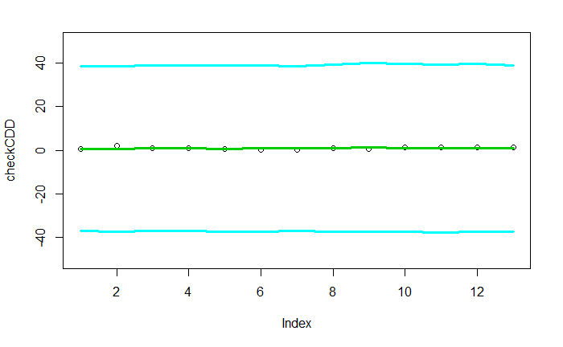

```r
lines(pdmd_lowerCDD,col=5,lwd=3)
lines(pdmd_upperCDD,col=5,lwd=3)
```

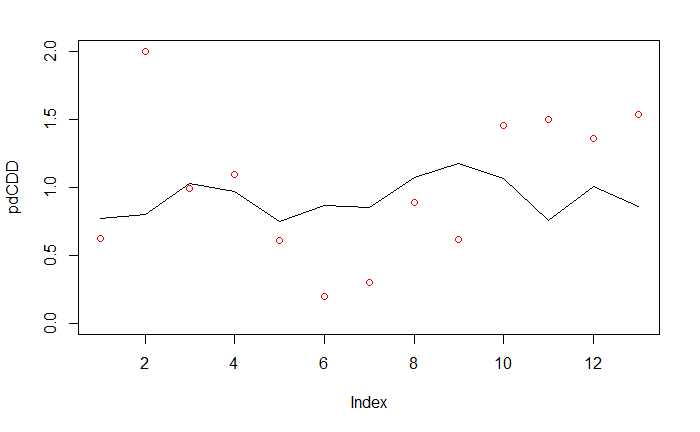

```r
colnames(pdfactorsCDD) <- c("Tmin","landT","time","Tmax","NINO3.4","SOI","PDO")
pdCDD <- predict(mdCDD,df_CDD[which(df_CDD[,2]>2005),])#pdfactors)
plot(pdCDD,type='l',ylim=c(0,2))
points(df_CDD[which(df_CDD[,2]>2005),1],col="red")
```

### For HDD

```r
df_HDD <- as.data.frame(cbind(seas_HDD[,2],NINO4SON,NAOSON[,2],AMOSON[,2],landTSON[,2],Tmin_SON[,2],Tmax_SON[,2]))
summ <-summary(mdHDD)
colnames(df_HDD) <- c("HDD","time","NINO4","NAO","AMO","landT","Tmin","Tmax")
b=summ$coefficients[,1]
sd=summ$coefficients[,2]
tval=summ$coefficients[,3]
cf_lower=b-sd
cf_upper=b+sd#confint(mdHDD)[,2]
checkHDD <-seas_HDD[which(seas_HDD[,1]>2005),2]
pdTminHDD=Tmin_SON[which(Tmin_SON[,1]>2005),2]
pdAMOHDD=AMOSON[which(AMOSON[,1]>2005),2]
pdtimeHDD=Tmin_SON[which(Tmin_SON[,1]>2005),1]
pdNAOHDD=NAOSON[which(NAOSON[,1]>2005),2]
pdlandTHDD=landTSON[which(landTSON[,1]>2005),2]
pdNINO4HDD=NINO4SON[which(NINO4SON[,1]>2005),2]
pdfactorsHDD=as.data.frame(cbind(pdTminHDD,pdtimeHDD,pdNINO4HDD,pdlandTHDD,pdNAOHDD,pdAMOHDD))
pd <- function(b,pdfactor){
  pd=b[1]+b[2]*pdfactor[,1]+b[3]*pdfactor[,2]+b[4]*pdfactor[,3]+b[5]*pdfactor[,4]+b[6]*pdfactor[,5]+b[7]*pdfactor[,6]
}
pdmdHDD=pd(b,pdfactorsHDD)
pdmd_lowerHDD=pd(cf_lower,pdfactorsHDD)
pdmd_upperHDD=pd(cf_upper,pdfactorsHDD)
plot(checkHDD,ylim=c(-45,45))
lines(pdmdHDD,col=3,lwd=3)
```

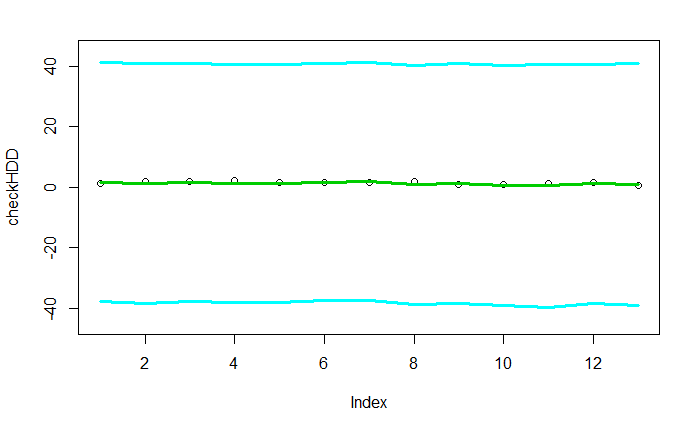

```r
lines(pdmd_lowerHDD,col=5,lwd=3)
lines(pdmd_upperHDD,col=5,lwd=3)
```

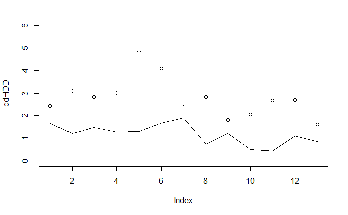

```r
colnames(pdfactorsHDD) <- c("Tmin","time","NINO4","landT","NAO","AMO")
pdHDD <- predict(mdHDD,df_HDD[which(df_HDD[,2]>2005),])#pdfactors)
plot(pdHDD,type='l',ylim=c(0,6))
points(df_HDD$HDD)
```

6. As an alternative way to quantify uncertainty in the regression model, perform a residual bootstrap (see below). Plot bootstrap distributions of a few key regression parameters, and compare the variability with that from the 95% intervals that your machine will spit out. ###For CDD###

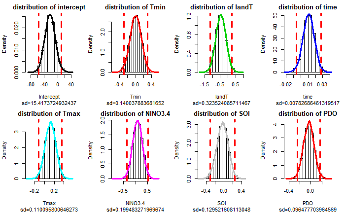

### For HDD

```r
df_HDDshort=df_HDD[which(df_HDD[,2]<=2005),]
pdHDDtrain=predict(mdHDD,df_HDDshort)
epsiHDD=df_HDDshort[,1]-pdHDDtrain
paramHDD=array(0,dim=c(10000,7))
for(i in 1:10000){
  HDDtraintmp=pdHDDtrain+sample(epsiHDD,size=length(epsiHDD),replace=TRUE)
  df_HDDshort[,1]=HDDtraintmp
  md <-lm(HDD~Tmin+time+NINO4+landT+NAO+AMO,data=df_HDDshort)
  paramHDD[i,]=md$coefficients
}
par(mfrow=c(2,4))
hist(paramHDD[,1],prob=TRUE,xlab="Intercept",main="distribution of intercept",sub=paste0("sd=",sd(paramHDD[,1])))
abline(v=confint(mdHDD)[1,1],lwd=3,col="red",lty=2)
```

```r
abline(v=confint(mdHDD)[1,2],lwd=3,col="red",lty=2)
lines(density(paramHDD[,1]),col=1,lwd=3)
```

```r
hist(paramHDD[,2],prob=TRUE,xlab="Tmin",main="distribution of Tmin",sub=paste0("sd=",sd(paramHDD[,2])))
abline(v=confint(mdHDD)[2,1],lwd=3,col="red",lty=2)
```

```r
abline(v=confint(mdHDD)[2,2],lwd=3,col="red",lty=2)
lines(density(paramHDD[,2]),col=2,lwd=3)
```

```r
hist(paramHDD[,3],prob=TRUE,xlab="time",main="distribution of time",sub=paste0("sd=",sd(paramHDD[,3])))
abline(v=confint(mdHDD)[3,1],lwd=3,col="red",lty=2)
```

```r
abline(v=confint(mdHDD)[3,2],lwd=3,col="red",lty=2)
lines(density(paramHDD[,3]),col=3,lwd=3)
```

```r
hist(paramHDD[,4],prob=TRUE,xlab="NINO4",main="distribution of NINO4",sub=paste0("sd=",sd(paramHDD[,4])))
abline(v=confint(mdHDD)[4,1],lwd=3,col="red",lty=2)
```

```r
abline(v=confint(mdHDD)[4,2],lwd=3,col="red",lty=2)
lines(density(paramHDD[,4]),col=4,lwd=3)
```

```r
hist(paramHDD[,5],prob=TRUE,xlab="landT",main="distribution of landT",sub=paste0("sd=",sd(paramHDD[,5])))
abline(v=confint(mdHDD)[5,1],lwd=3,col="red",lty=2)
```

```r
abline(v=confint(mdHDD)[5,2],lwd=3,col="red",lty=2)
lines(density(paramHDD[,5]),col=5,lwd=3)
```

```r
hist(paramHDD[,6],prob=TRUE,xlab="NAO",main="distribution of NAO",sub=paste0("sd=",sd(paramHDD[,6])))
abline(v=confint(mdHDD)[6,1],lwd=3,col="red",lty=2)
```

```r
abline(v=confint(mdHDD)[6,2],lwd=3,col="red",lty=2)
lines(density(paramHDD[,6]),col=6,lwd=3)
```

```r
hist(paramHDD[,7],prob=TRUE,xlab="AMO",main="distribution of AMO",sub=paste0("sd=",sd(paramHDD[,7])))
abline(v=confint(mdHDD)[7,1],lwd=3,col="red",lty=2)
```

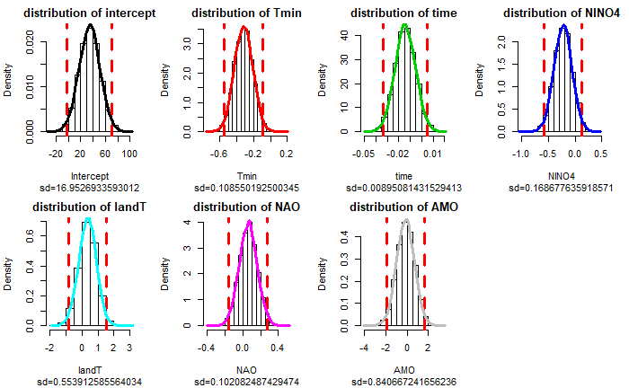

```r
abline(v=confint(mdHDD)[7,2],lwd=3,col="red",lty=2)
lines(density(paramHDD[,7]),col=8,lwd=3)
```

7. End with a short write up of results, explaining what you found and if your model should be used by the energy trading desk. According to results from question (d), the models cannot capture the variance of the original time series very well, the estimated values using the training dataset are confined within a small range, while the real time series has much larger variance, probably because non of the predictor time series can provide the same magnitude of variance as the HDD and CDD time series (see results in question (a)). A comparison of the parameter variance shows that the parameter with the largest variance is usually interception, this is understandable because the predictors have small variance, the variance of the real time series can hardly be explained by any of the predictors except the interception. However, this expression of variance in the model is not true, and leads to results that the models yield bad predictions for 2006-2018 HDD and CDD values – the model either cannot capture the value’s variation or the uncertainty of the predicted time series is so large that we cannot even draw any conclusions of prediction with confidence from the models’ results. Therefore, this model shouldn’t be used by the energy trading desk. However, if we do not estimate the HDD and CDD directly, instead estimate the standardized anomaly of HDD and CDD based on a certain constant level, the models we build may be able to do a better job, since the variance difference between the anomalies and the climate indices might be smaller.